# Unit 2 Module 1

Spatial Data Analysis with R (01:450:320)

# 1 Working with spatial vector data

In this section we will start to work with spatial vector data, learning the most common forms of vector-based spatial operations. We will be working primarily with the `sf` package, which replaces the earlier `sp` package.

The material in this section assumes that the reader is familiar with standard GIS operations and concepts, ranging from projections and transformations to intersections, buffers, and differences.

# 2 Preparation

## 2.1 Set-up

Let’s start by loading `sdadata`.

```r
# A reminder of how to install
# devtools::install_github("SSELP/sdadata")
library(sdadata)
```

`sdadata` imports `sf`. `sf` depends on the following external libraries (from [here](https://cran.r-project.org/web/packages/sf/index.html)):

> SystemRequirements: GDAL (>= 2.0.1), GEOS (>= 3.4.0), PROJ (>= 4.8.0), sqlite3

These are external libraries that provide key geospatial capabilities that are used by `R` and many other languages and platforms that can be used for geospatial analytics. If you are using the docker container, these are already installed so you don’t have to worry about them. Read more about them by following these links: [GDAL](https://gdal.org/), [GEOS](https://libgeos.org/), [PROJ](https://proj.org/en/9.3/), [sqlite3](https://www.sqlite.org/index.html)

You should already have your class Rstudio project (e.g. ls320) setup, with a `notebooks/` folder within it. If you don’t already have it, create a `data/` folder within `notebooks/`, which is where you will practice writing spatial data files.

# 3 Reading, writing, and making vector data

This reading introduces reading, writing, and making vector data, how to work with their coordinate reference systems (CRS), and how to do some basic plotting, leavened with some additional `R` programming examples. However, the first thing we need to do is learn about simple features, which is the representation of vector data that is employed by `sf` (which stands for simple features).

## 3.1 Simple features, explained

To learn more about what simple features are and how they work, and why `R` developed a package for them, please read the `sf` introductory [vignette](https://r-spatial.github.io/sf/articles/sf1.html) written by Edzer Pebesma, the primary `sf` package developer.

## 3.2 From non-spatial to spatial

We are going to start by reading in the `species` dataset, which installs with `sdadata`. It contains occurrence records for the “Big Five” (Elephant, Lion, Leopard, Buffalo, and Rhinoceros) in Tanzania, sourced from the [Global Biodiversity Information Facility (GBIF)](https://www.gbif.org). This dataset is a subset that contains the following variables:

- family: The biological family to which the species belongs (e.g., Felidae or Elephantidae).
- species: The scientific name of the animal (e.g., Panthera leo).
- month: The month of the year the observation was recorded (1−12)
- year: The year of the observation, allowing for analysis of trends over time.
- x: Longitude in decimal degrees.
- y: Latitude in decimal degrees.

Here’s a quick look:

```r
# Chunk 1
species <- read_csv(system.file("extdata/species.csv", package = "sdadata"))
#
# 1
set.seed(30)
species %>%
  sample_n(5) %>%
  arrange(year, month)
```

```
#> # A tibble: 5 × 6
#>   family       species            month  year     x     y
#>   <chr>        <chr>              <dbl> <dbl> <dbl> <dbl>
#> 1 Felidae      Panthera leo          10  2018  34.9 -2.42
#> 2 Elephantidae Loxodonta africana     1  2023  36.1 -4.05
#> 3 Felidae      Panthera leo           1  2024  36.1 -3.78
#> 4 Elephantidae Loxodonta africana     8  2024  36.1 -3.67
#> 5 Elephantidae Loxodonta africana     3  2025  34.9 -2.60
```

```r
#
# #2
species %>%
  distinct(species) %>%
  count()
```

```
#> # A tibble: 1 × 1
#>       n
#>   <int>
#> 1     5
```

```r
#
# #3
species %>%
  group_by(species, year) %>%
  count() %>%
  arrange(year)
```

```
#> # A tibble: 133 × 3
#> # Groups:   species, year [133]
#>    species             year     n
#>    <chr>              <dbl> <int>
#>  1 Loxodonta africana  2000     4
#>  2 Panthera leo        2000     2
#>  3 Panthera pardus     2000     2
#>  4 Syncerus caffer     2000     4
#>  5 Loxodonta africana  2001     5
#>  6 Panthera leo        2001     9
#>  7 Panthera pardus     2001     2
#>  8 Syncerus caffer     2001     2
#>  9 Diceros bicornis    2002     1
#> 10 Loxodonta africana  2002     4
#> # ℹ 123 more rows
```

Okay, #1 shows us that this dataset, read in as `species`, is a `tibble`, which means it is non-spatial at the moment, even though its comes with coordinates. #2 shows us that there are 5 species (big five) in the dataset, and #3 shows a varying number of observations per species per year.

Given that these are point data, we can turn them into a facsimile of spatial data by simply plotting them and having a look.

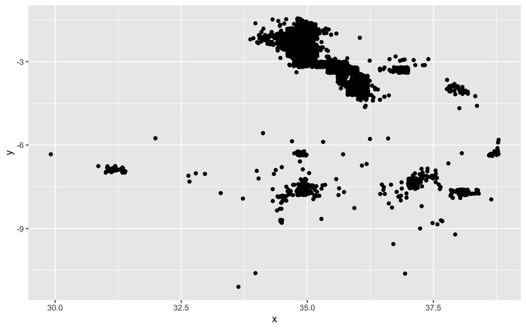

```r
# Chunk 2
ggplot(species %>% distinct(species, x, y)) +
  geom_point(aes(x, y))
```

To avoid possible duplicate points, we first cut `species` down to just unique species records and coordinates (GBIF data is messy), and then use `gglot` to shows us, in a very crude way, where these points lie in space. This works, because `species$x` (the longitude) is exactly analogous to the x coordinate of a scatter plot, and `species$y` (latitude) is the y coordinate. But it is still not a spatial object. So, let’s convert it to one, and then plot it again.

```r
# Chunk 3
# #1
species <- st_as_sf(species, coords = c("x", "y"))
species
```

```
#> Simple feature collection with 6951 features and 4 fields
#> Geometry type: POINT
#> Dimension:     XY
#> Bounding box:  xmin: 29.91544 ymin: -11.09595 xmax: 38.79323 ymax: -1.44546
#> CRS:           NA
#> # A tibble: 6,951 × 5
#>    family       species            month  year             geometry
#>    <chr>        <chr>              <dbl> <dbl>              <POINT>
#>  1 Elephantidae Loxodonta africana     6  2012 (34.08678 -2.276964)
#>  2 Bovidae      Syncerus caffer        6  2012   (35.75882 -3.5614)
#>  3 Bovidae      Syncerus caffer        6  2012 (35.44965 -3.230564)
#>  4 Felidae      Panthera pardus        6  2012 (34.96447 -2.475424)
#>  5 Elephantidae Loxodonta africana     6  2012 (35.13262 -1.883995)
#>  6 Bovidae      Syncerus caffer        6  2012   (35.73392 -3.0035)
#>  7 Elephantidae Loxodonta africana     6  2012 (35.61116 -3.004654)
#>  8 Elephantidae Loxodonta africana     6  2012 (35.97219 -3.429279)
#>  9 Bovidae      Syncerus caffer        6  2012 (35.12084 -1.948731)
#> 10 Elephantidae Loxodonta africana     6  2012 (35.03655 -1.983431)
#> # ℹ 6,941 more rows
```

```r
#
# #2
str(species)
```

```
#> sf [6,951 × 5] (S3: sf/tbl_df/tbl/data.frame)
#>  $ family  : chr [1:6951] "Elephantidae" "Bovidae" "Bovidae" "Felidae" ...
#>  $ species : chr [1:6951] "Loxodonta africana" "Syncerus caffer" "Syncerus caffer" "Panthera pardus" ...
#>  $ month   : num [1:6951] 6 6 6 6 6 6 6 6 6 6 ...
#>  $ year    : num [1:6951] 2012 2012 2012 2012 2012 ...
#>  $ geometry:sfc_POINT of length 6951; first list element:  'XY' num [1:2] 34.09 -2.28
#>  - attr(*, "sf_column")= chr "geometry"
#>  - attr(*, "agr")= Factor w/ 3 levels "constant","aggregate",..: NA NA NA NA
#>   ..- attr(*, "names")= chr [1:4] "family" "species" "month" "year"
```

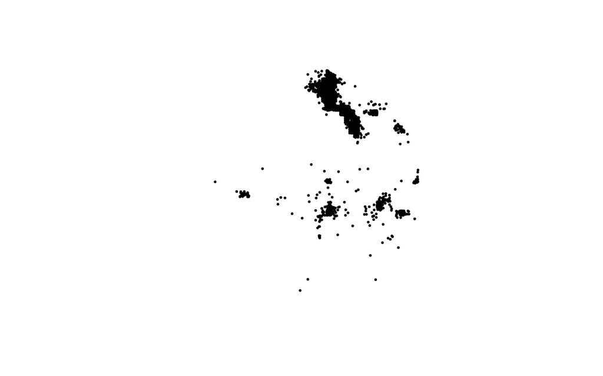

```r
#
# #2
plot(st_geometry(species), pch = 20, cex = 0.5)
```

In #1, we use our first function from `sf`, which is `st_as_sf`, which is used to “convert foreign object to an sf object” (`?st_as_sf`). In this case we coerce a `data.frame`/`tibble` into an `sf` POINT object, by specifying the x and y coordinates for the “coords” argument. The summary of `species`, now an `sf` object, displays metadata describing the number of features and variables, the geometry type, the number of dimensions, the object’s bounding box (bbox), its spatial reference system information (EPSG string and proj4string; more on these later), which are currently not set, and then it shows the `tibble` with values. *x* and *y* no longer occur, and have been replaced by a geometry column now.

Looking at `str` in #2, we see the object is constructed of 4 classes (`sf`, `tbl_df`, `tbl`, and `data.frame`), with the geometry variable being of class `sfc_POINT`. Please refer back to the [how simple features are organized](https://r-spatial.github.io/sf/articles/sf1.html#how-simple-features-in-r-are-organized) section on the `sf` website to understand how the geometry is structured.

We then `plot` the new `sf` object, using `st_geometry` to strip out the geometries of this object, dropping the other variables in the `tibble` with associated with the object. The reason for this is that `plot` (`sf`’s generic for plotting `sf` objects) would otherwise default to creating one plot panel for each variable in the `tibble`. We can see this behavior here by comparison:

```r
# Chunk 4
## With st_geometry
plot(species %>% slice(1:10) %>% st_geometry(), pch = 20, cex = 0.5)
```

[output not shown]

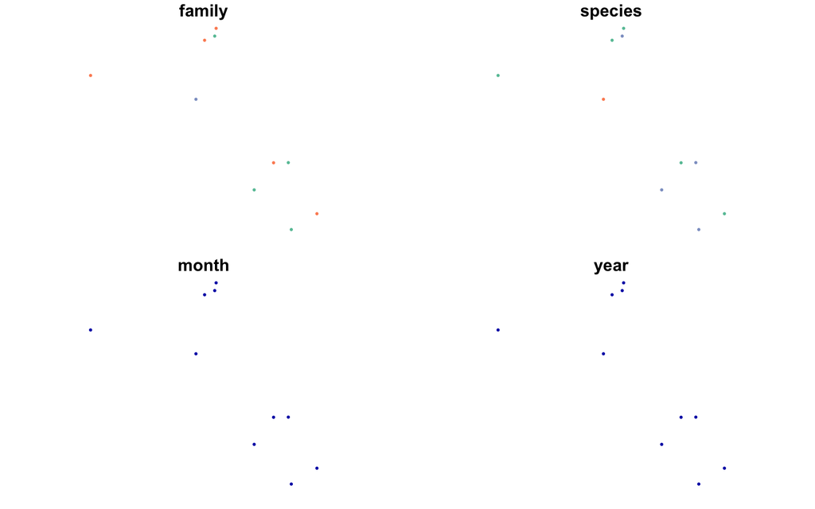

```r
## No st_geometry
plot(species %>% slice(1:10), pch = 20, cex = 0.5)
```

In the above, we illustrate this multi-panel plotting behavior using just the first 10 rows of `species`, using `dplyr` syntax to `slice` out those rows, in the process illustrating that `sf` is designed to work with the `tidyverse`.

So, in Chunk 3 above, we have seen how we can coerce the non-spatial `species` into a spatial object `sf`. We can coerce `species` back to an ordinary `data.frame`/`tibble` by simply doing this:

```r
# Chunk 5
species %>% as_tibble
```

```
#> # A tibble: 6,951 × 5
#>    family       species            month  year             geometry
#>    <chr>        <chr>              <dbl> <dbl>              <POINT>
#>  1 Elephantidae Loxodonta africana     6  2012 (34.08678 -2.276964)
#>  2 Bovidae      Syncerus caffer        6  2012   (35.75882 -3.5614)
#>  3 Bovidae      Syncerus caffer        6  2012 (35.44965 -3.230564)
#>  4 Felidae      Panthera pardus        6  2012 (34.96447 -2.475424)
#>  5 Elephantidae Loxodonta africana     6  2012 (35.13262 -1.883995)
#>  6 Bovidae      Syncerus caffer        6  2012   (35.73392 -3.0035)
#>  7 Elephantidae Loxodonta africana     6  2012 (35.61116 -3.004654)
#>  8 Elephantidae Loxodonta africana     6  2012 (35.97219 -3.429279)
#>  9 Bovidae      Syncerus caffer        6  2012 (35.12084 -1.948731)
#> 10 Elephantidae Loxodonta africana     6  2012 (35.03655 -1.983431)
#> # ℹ 6,941 more rows
```

This gets us back to a `tibble`, but the *x* and *y* variables do not reappear, instead we still have the geometry column. If we want to get back to the original structure of the `tibble`, its more complicated, but certainly possible:

```r
# Chunk 6
bind_cols(species %>% st_drop_geometry(),
          st_coordinates(species) %>% as_tibble()) %>%
  select(family, species, month, year, X, Y) %>%
  rename(x = X, y = Y)
```

```
#> # A tibble: 6,951 × 6
#>    family       species            month  year     x     y
#>    <chr>        <chr>              <dbl> <dbl> <dbl> <dbl>
#>  1 Elephantidae Loxodonta africana     6  2012  34.1 -2.28
#>  2 Bovidae      Syncerus caffer        6  2012  35.8 -3.56
#>  3 Bovidae      Syncerus caffer        6  2012  35.4 -3.23
#>  4 Felidae      Panthera pardus        6  2012  35.0 -2.48
#>  5 Elephantidae Loxodonta africana     6  2012  35.1 -1.88
#>  6 Bovidae      Syncerus caffer        6  2012  35.7 -3.00
#>  7 Elephantidae Loxodonta africana     6  2012  35.6 -3.00
#>  8 Elephantidae Loxodonta africana     6  2012  36.0 -3.43
#>  9 Bovidae      Syncerus caffer        6  2012  35.1 -1.95
#> 10 Elephantidae Loxodonta africana     6  2012  35.0 -1.98
#> # ℹ 6,941 more rows
```

We drop the `geometry` of `species`, and then we use `dplyr::bind_cols` (equivalent to `cbind`) to bind the coordinates back to the `tibble`. The coordinates are obtained using `st_coordinates`, an `sf` function used to “retrieve coordinates in matrix form” (`?st_coordinate`), and we have to coerce that to a `tibble` for `bind_cols` to work. We can use `select` to reorder the columns in their original form, and rename the coordinate columns back to their original lower case (`st_coordinates` returns *X* and *Y* columns). This is a standard way for geoscientists to convert spatial data back and forth.

## 3.3 Read and write spatial data

That was a very quick dip into spatial waters, using a points example. We are going to learn to read and write (in reverse order) spatial data. We still have `species` back as an sf object. We are now going to write it out to a spatial file.

```r
# Chunk 6
st_write(obj = species, dsn = file.path(tempdir(), "species.shp"),
         delete_dsn = TRUE)
```

```
#> writing: substituting ENGCRS["Undefined Cartesian SRS with unknown unit"] for missing CRS
#> Warning in CPL_write_ogr(obj, dsn, layer, driver, as.character(dataset_options), : GDAL Error 1:
#> /var/folders/8z/trk9m2ks7ksd2s963fkz3dg80000gq/T//Rtmpsj1f3M/species.shp does not appear to be a
#> file or directory.
#> Deleting source `/var/folders/8z/trk9m2ks7ksd2s963fkz3dg80000gq/T//Rtmpsj1f3M/species.shp' failed
#> Writing layer `species' to data source
#>   `/var/folders/8z/trk9m2ks7ksd2s963fkz3dg80000gq/T//Rtmpsj1f3M/species.shp' using driver `ESRI Shapefile'
#> Writing 6951 features with 4 fields and geometry type Point.
```

```r
dir(tempdir(), pattern = "species")
```

```
#> [1] "species.dbf" "species.prj" "species.shp" "species.shx"
```

The code above uses `st_write` to create that old standby, the ESRI shapefile, that clunky, annoying format that has many files for one thing. Note that I have the option `delete_dsn = TRUE` set, which is needed if the file already exists in that location, and you want to recreate it (which I did in this case, because I was re-running this code many times as I wrote this). For `st_write`, the “obj” argument asks for the `sf` object to write, “dsn” is the name and path for the output file. By adding the “.shp” at the end of the filename, `st_write` knows to use the “ESRI Shapefile” driver. For this example, I used again the `tempdir()` function to write this object to a temporary directory, but, as you follow along, *you should change the file path to correctly lead to your own `xyz320/notebooks/data` path*.

```r
# Chunk 7
species %>% st_crs()
```

```
#> Coordinate Reference System: NA
```

`species` does not have a coordinate reference system (CRS) associated with it yet, even though we can tell it is in geographic coordinates. Remember this, because we will come back to it.

Because .shp is an annoying format, we can try other types. Let’s do the much more convenient “geojson” format, which produces a single file.

```r
# Chunk 8
st_write(obj = species, dsn = file.path(tempdir(), "species.geojson"),
         delete_dsn = TRUE)
```

```
#> writing: substituting ENGCRS["Undefined Cartesian SRS with unknown unit"] for missing CRS
#> Deleting source `/var/folders/8z/trk9m2ks7ksd2s963fkz3dg80000gq/T//Rtmpsj1f3M/species.geojson' failed
#> Writing layer `species' to data source
#>   `/var/folders/8z/trk9m2ks7ksd2s963fkz3dg80000gq/T//Rtmpsj1f3M/species.geojson' using driver `GeoJSON'
#> Writing 6951 features with 4 fields and geometry type Point.
```

```r
dir(tempdir(), pattern = "species")
```

```
#> [1] "species.dbf"     "species.geojson" "species.prj"     "species.shp"     "species.shx"
```

```r
# Chunk 9
file.remove(dir(tempdir(), pattern = "species.geojson", full.names = TRUE))
```

```
#> [1] TRUE
```

```r
rm(species)
species <- st_read(dir(tempdir(), pattern = "species.shp", full.names = TRUE))
```

Now, there are two more datasets that come with `sdadata` to read in using `st_read`: `roads.geojson` and `districts.geojson`. The paths to both are found with the `system.file` function. I’ll set up the first one for you.

```r
# Chunk 10
fnm <- system.file("extdata/roads.geojson", package = "sdadata")
roads <- st_read(dsn = fnm) #%>% st_set_crs("ESRI:102022")
fnm <- system.file("extdata/districts.geojson", package = "sdadata")
districts <- st_read(dsn = fnm)
```

Let’s end this section by a quick look at these data. We are going to plot `districts`, `roads`, and `species` onto one plot.

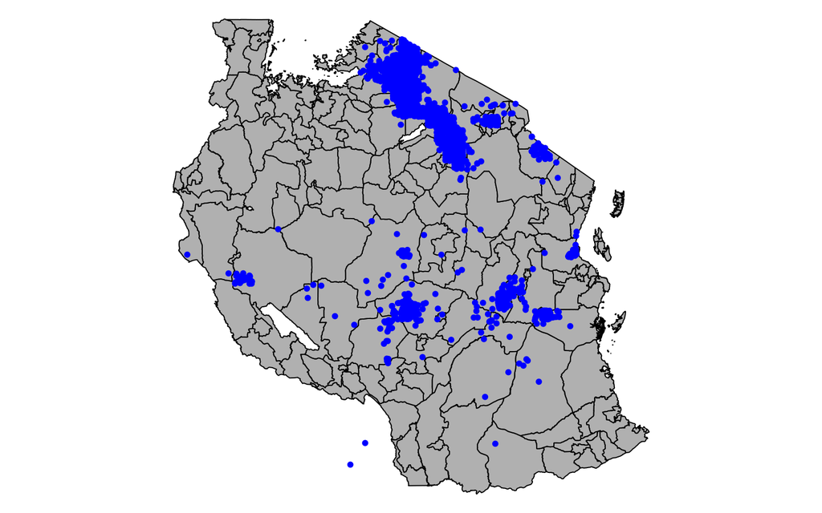

```r
# Chunk 11
par(mar = c(0, 0, 0, 0))
plot(st_geometry(districts), col = "grey")
plot(st_geometry(roads), col = "red", add = TRUE)
plot(st_geometry(species), pch = 20, reset = FALSE, col = "blue", add = TRUE)
```

So what have we done? First, we use the `par` function with the `mar` (margin) argument and a 4-element vector of 0s to remove the inner margins of the plot so that the map of Tanzania fills the plot frame. We then use `plot` to draw the map of `districts` (wrapped in `st_geometry`, to just grab the geometry part), which are administrative boundaries for Tanzania. We then use lines to add `roads` on top of that, making them red. Finally, we add the `species` data as blue points. Note the use of `add = TRUE`, which is necessary to overlay the two plots on the `district` boundaries without creating a new plot of each.

That’s great, you say, but I see no `roads` in the map. Where are they? And why are there two species outside of Tanzania?

## 3.4 Coordinate Reference Systems and Projections

The reason you can’t see the roads on the previous map can be illustrated as follows:

```r
# Chunk 12
sfdat <- list("districts" = districts,  "roads" = roads, "species" = species)
sapply(sfdat, function(x) st_bbox(x))
```

```
#>       districts      roads   species
#> xmin  29.589529   478749.8  29.91544
#> ymin -11.762349 -1385619.0 -11.09595
#> xmax  40.444735  1591587.5  38.79323
#> ymax  -0.983143  -118296.2  -1.44546
```

In the code above, we add our 3 `sf` objects into a `list` (`sfdat`), and then use `sapply` to apply `st_bbox` to each list element to get their bounding boxes. That produces an output matrix that shows in the westernmost (xmin), southernmost (ymin), easternmost (xmax), and northernmost (ymax) coordinates of each object. This shows us that `roads`’ coordinates are in different units (meters) than `districts`’ and `species`’, which are decimal degrees. So when we tried to plot `roads` on the same map as `districts` and `species`, `roads` didn’t appear because the units are not the same. You could get a map of `roads` if you plotted them on their own.

### 3.4.1 Checking the CRS of an `sf` object

In this case, we have to do a bit more, which is to convert `roads` coordinate reference system (CRS) to decimal degrees. How do we do that? First, we have to know the crs we want to transform `roads` into, which we can do by checking the `st_crs` of `species` or `districts`:

```r
# Chunk 13
st_crs(districts)$proj4string
```

```
#> [1] "+proj=longlat +datum=WGS84 +no_defs"
```

```r
st_crs(roads)$proj4string
```

```
#> [1] "+proj=aea +lat_0=0 +lon_0=25 +lat_1=20 +lat_2=-23 +x_0=0 +y_0=0 +datum=WGS84 +units=m +no_defs"
```

We use `st_crs`, which is `sf`’s function for checking and assigning a CRS to an `sf` object. When you run it as we have done with `st_crs(districts)`, it returns an object of class `crs` (you can verify that by running `class(st_crs(districts))`). We see that `districts` and `roads` have different values in their “PROJCRS” fields, which holds the projection string that contains the projection parameters of the CRS. If you want to understand the meaning of projection string parameters, please have a look at the [documentation](http://proj4.org) for the `proj.4` library, specifically the page on [parameters](http://proj4.org/parameters.html).

This one basically tells us that `districts` has a geographic (longlat) projection, and uses the WGS84 datum. Let’s check the crs for all three objects now, using our old friend `sapply`

```r
# Chunk 14
sapply(sfdat, function(x) st_crs(x)$proj4string)
```

```
#>                                                                                        districts
#>                                                            "+proj=longlat +datum=WGS84 +no_defs"
#>                                                                                            roads
#> "+proj=aea +lat_0=0 +lon_0=25 +lat_1=20 +lat_2=-23 +x_0=0 +y_0=0 +datum=WGS84 +units=m +no_defs"
#>                                                                                          species
#>                                                                                               NA
```

These results show us that `species` does not have a projection string. So how come it was able to plot on the same map as `districts`? Because the coordinates are in the same units. However, we want to fix that before we move to the next step, reprojecting:

```r
# Chunk 15
st_crs(species) <- st_crs(districts)
st_crs(sfdat$species) <- st_crs(districts)
st_crs(sfdat$species)$proj4string
```

```
#> [1] "+proj=longlat +datum=WGS84 +no_defs"
```

Simple–we apply the fix to `species` and to `sfdat$species` by assigning each the proj4string from `districts`. We can do that because we are pretty sure that the coordinates for species are from a geographic coordinate system that uses the WGS84 datum. If that is incorrect, we are introducing some spatial error. But for now, this is fine.

Another note, when running `st_crs`, we are extracting the `proj4string` element from the resulting `crs` object. That is because it provides a more compact string representation of the CRS information. Running `st_crs(sfdat$species)` produces a much lengthier (and more informative) output in `wkt` format. Go ahead and try that.

### 3.4.2 Reprojecting

Okay, so now we want to change `roads` to the same CRS as `districts`.

```r
# Chunk 16
sfdat$roads <- st_transform(x = sfdat$roads, crs = st_crs(districts))
```

We use `sf`‘s `st_transform` function to reproject `sfdat$roads` using the parameters supplied by `districts`’ p4s, which is passed into the function’s “crs” argument via the `st_crs` function applied to `districts`.

And that’s all. We can now redo our plots. I am going to show you two ways to do it. First, the way we have already done it with `sf:plot`:

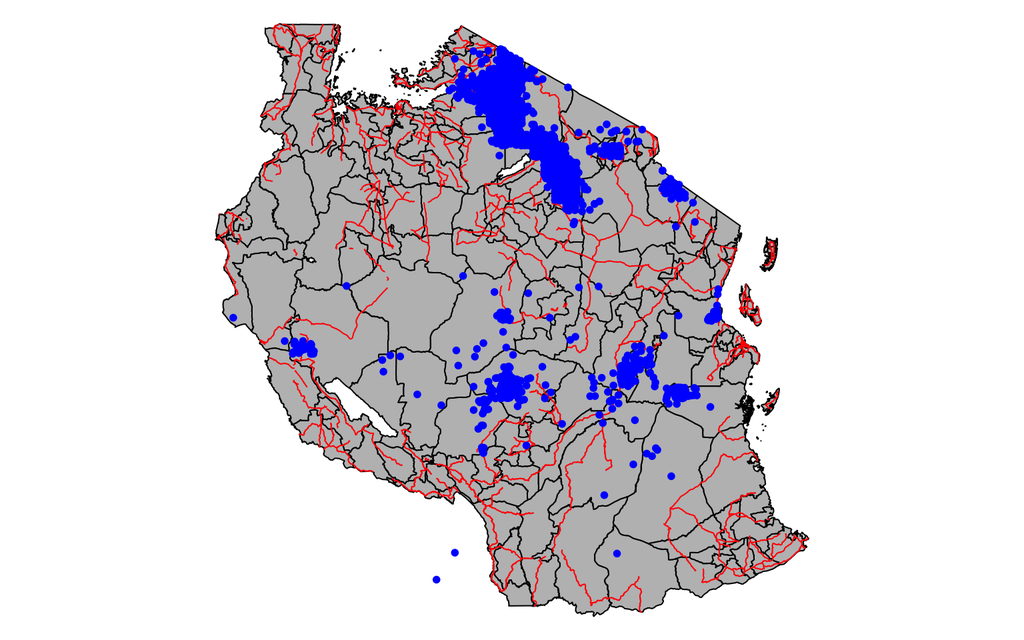

```r
# Chunk 17
par(mar = c(0, 0, 0, 0))
plot(sfdat$districts %>% st_geometry(), col = "grey")
plot(sfdat$roads %>% st_geometry(), col = "red", add = TRUE)
plot(sfdat$species %>% st_geometry(), col = "blue", pch = 20, add = TRUE)
```

And with `ggplot`:

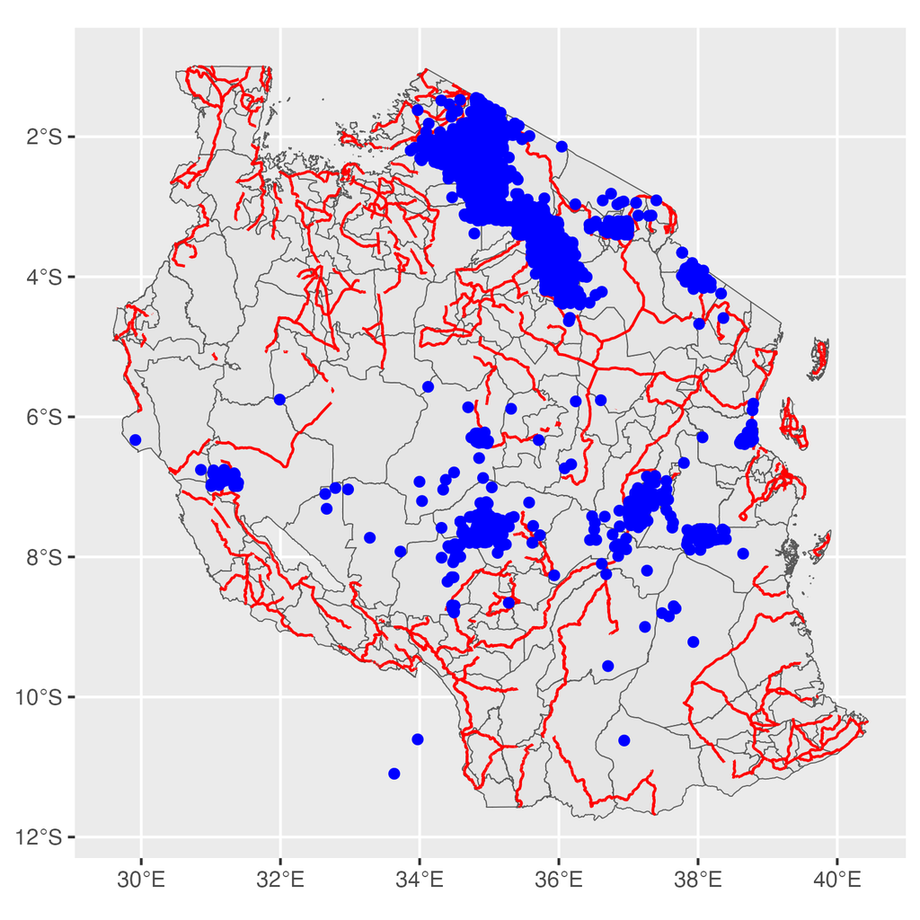

```r
# Chunk 18
ggplot(sfdat$districts) + geom_sf() +
  geom_sf(data = sfdat$roads, col = "red") +
  geom_sf(data = sfdat$species, col = "blue")
```

So now you see the roads appearing as red lines on the map. `ggplot` adds a coordinate grid to the outside of the plot, and has a special function `geom_sf` that is designed to plot `sf` geometries. However, it is still substantially slower than `sf::plot` for the time being, so we’ll mostly stick with the latter.

## 3.5 Making simple features from scratch

Before ending this section, it is worth looking at how we can make our own `sf` objects from scratch, which we might need to do from time to time.

```r
# Chunk 19
# #1
pt <- st_point(x = c(34, -6))
pt
```

```
#> POINT (34 -6)
```

```r
#
# #2
pts <- st_multipoint(x = cbind(x = c(35.5, 36, 36.5), y = c(-5, -5.5, -6)))
pts
```

```
#> MULTIPOINT ((35.5 -5), (36 -5.5), (36.5 -6))
```

```r
#
# #3
sline <- st_linestring(cbind(x = c(35, 35.5, 36), y = c(-5.5, -6, -6.5)))
sline
```

```
#> LINESTRING (35 -5.5, 35.5 -6, 36 -6.5)
```

```r
#
# #4
pol <- st_polygon(list(cbind(x = c(34.5, 35.5, 35, 34, 34.5),
                             y = c(-6, -7, -7.5, -6.5, -6))))
pol
```

```
#> POLYGON ((34.5 -6, 35.5 -7, 35 -7.5, 34 -6.5, 34.5 -6))
```

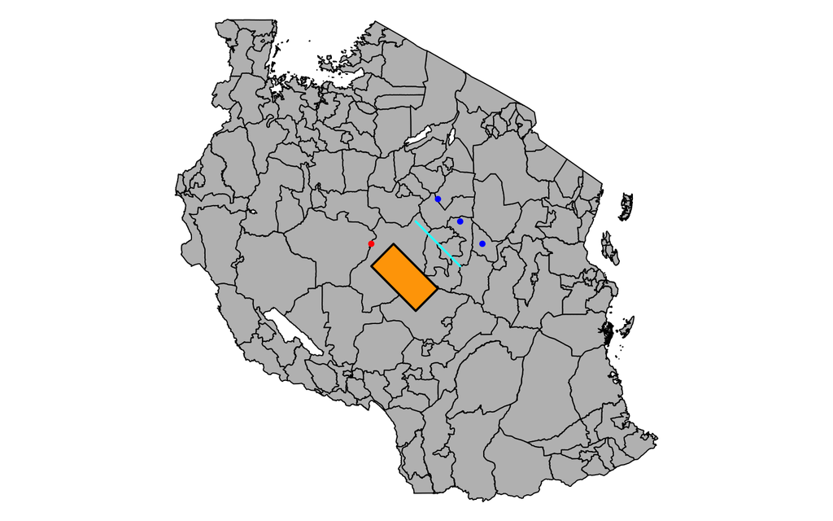

```r
#
# 5
par(mar = c(0, 0, 0, 0))
plot(districts %>% st_geometry(), col = "grey")
plot(pt, add = TRUE, col = "red", pch = 20)
plot(pts, add = TRUE, col = "blue", pch = 20)
plot(sline, add = TRUE, col = "cyan", lwd = 2)
plot(pol, add = TRUE, col = "orange", lwd = 2)
```

We use `st_point` in #1 to create a single point object, based on a two-element vector that consists of the x and y coordinate. In #2, `st_multipoint` create an object with three points, based on an matrix containing the x coordinates in the first column and y coordinates in second column. #3 convert a similar matrix of coordinates into an `st_linestring`, and #4 creates a polygon object, also using a matrix as input–note that the first and last coordinates in both the x and y coordinates are the same, which is done in order to close the polygon. The printout of each `sfg` (simple feature geometry) shows that they store coordinates as point pairs separated by commas (except for `pt`, since it is just a single point). In #5 we plot each object over the `districts` polygons.

We’ll go bit further in making new features in the section on spatial operations

## 3.6 Practice

### 3.6.1 Questions

1. What are the primary simple feature geometry types?
2. How do you convert a `tibble` (or `data.frame`) into an `sf` object?
3. When plotting (mapping) `sf` objects, what happens if your object has multiple variables?
4. When constructing new `sf` objects, in what format do you have to provide inputs to the `st_*` constructor functions. How does the input object differ in the case of a POLYGON versus MULTIPOINT or LINESTRING?

### 3.6.2 Code

1. Working with the `species` `sf` object, convert it to just a set of points without any other variables.
2. Write out `species` with it CRS set to the same as `districts` into an sqlite file within your `notebooks/data` folder. Remove the `species` object from your workspace, and then read back into `R` the sqlite you just wrote out.
3. Examine the `class` and `str` of `districts` and `roads`.
4. Create a plot of `roads`–just the geometries–and make the color of the lines blue.
5. Create a plot of `districts`, using `dplyr::select` to choose the *distName* variable from the objects `data.frame`. Set the title to “Tanzania Districts” using the “main” argument. Don’t specify a color.
6. Create an `st_multipoint` object using x coordinates of `c(35, 36, 37)` and y coordinates of `c(-5, -6, -7)`, and plot that over `districts` as orange points.

# 4 Spatial properties and attribute fields

We now begin to learn how to perform analyses with spatial vectors, starting with calculating basic spatial properties and manipulating the attribute tables associated with spatial vectors.

As you probably closed this project between Section 1 and 2, you will also need to reload the `roads`, `districts`, and `species` datasets (coercing the latter back to an `sf` object). The code in Section 1 will show you how to do that, but here is some code to recreate most of what we need:

```r
# Chunk 20
roads <- system.file("extdata/roads.geojson", package = "sdadata") %>% st_read()
districts <- system.file("extdata/districts.geojson", package = "sdadata") %>%
  st_read()
species <- system.file("extdata/species.csv", package = "sdadata") %>%
  read_csv() %>% st_as_sf(coords = c("x", "y"), crs = 4326)
```

This looks a bit different than what we did before. In this construction, we make use of `dplyr` pipes to do everything in one go for all three datasets. We pipe the file path to `roads.geojson` straight to `sf::st_read()`, and that reads in it as a one-liner. Same goes for `districts` (despite the line break). `species` gets the file path piped to `read_csv`, and then the coercion to `sf` happens right downstream. We add the `crs = 4326` argument to `st_as_sf` to provide the missing projection information (4326 is the EPSG identifier for GCS WGS84)

## 4.1 Spatial properties

First, due to recent changes in `sf`, and how it handles spherical geometries, we have to set the following:

```r
sf_use_s2(FALSE)
```

```
#> Spherical geometry (s2) switched off
```

Otherwise if we try to calculate lengths or create buffers of vectors that are in geographic coordinates systems, we get odd results.

### 4.1.1 Area

Using polygons to calculate area is a fairly basic but important spatial vector operation. To calculate meaningful areas, generally you need your data to be projected into a coordinate system in which area is one of the true properties. However, the function we are going to use, `sf::st_area`, will estimate area even for data in geographic coordinates.

```r
# Chunk 21
# #1
dist_areas <- districts %>% st_area()
dist_areas
#
# #2
dist_areas %>% units::set_units("ha")
#
# #3
dist_areas %>% units::set_units("km^2")
```

```
#> Units: [m^2]
#>   [1]  1237181424   266991880  3237796747  8064122142  1265947533  6981462233 15909001482
#>   [8]   364969525   538906808   728705613  5630896694  9132303284  7289672419  2607595710
#>  [15]  5792245985  3958699261  7455226936  8055578543  3074286510  4707386048  2280950383
#>  [22]  1606578879 18784745856   369109423  9243791258   572527986  7514438395  7463660843
#>  [29]  1617874960    83240902  5133730982  2506182100  2824869889  3502512919  3305058442
#>  [36]   231069002   295025066   229584392   234454737 29625841684 16941638272   318438971
#>  [43]  1506332304  2208746511  7195183068   911823145 13406516414   967687278    92676984
#>  [50] 10054389973   902810020  1345846714    63391414  1967428180  1470230691  6220454054
#>  [57]  1216778726   219107154   256032980   505758018   379464273 15000069365  5974912721
#>  [64]  1063850901 34313758593  5973961212  2515594227  5569089606   470998471  3674639527
#>  [71] 13131616674  3799582883 19817537139  3092906601  2167876971  1069975601    64836217
#>  [78]  2001857930 11157052367  1534469486 17506256581   755895744 14439000656  2812972831
#>  [85]   252548054  2155115205   217763048    15456587  1971609350 13545763762 11774234334
#>  [92] 12458010586   288349054  6631589820 23461563741  4005226578   753345006  3692082480
```

[output cut: 63 more lines]

Very simple to calculate area for each polygon in `districts`. Note that the default is to calculate m$^2$, but we can change that to hectares (in #2) using or km$^2$ (#3) using the function `units::set_units` (the `units` package is imported by `sf`). Note that only numbers with units can be operated together (e.g. `>|+...`). This is sometimes annoying, but safe.

So this was an estimate of area from a non-project dataset. How does that compare to area from a true equal area projection, such as the Albers Equal Area projection that `roads` is projected in:

```r
# Chunk 21
dist_areas_alb <- districts %>%
  st_transform(crs = st_crs(roads)) %>%
  st_area()
absd <- mean(abs(dist_areas_alb - dist_areas)) %>% units::set_units("ha")
pctd <- as.numeric(absd / (mean(dist_areas_alb) / 10000)) * 100
absd
```

```
#> 0.1048738 [ha]
```

```r
pctd
```

```
#> [1] 2.017064e-05
```

Using `st_transform` with the CRS from `roads` to reproject `district`, and then calculate polygons areas, we see the mean absolute difference between areas calculated from the projected and unprojected datasets is around 0 ha, which is a tiny percentage (0%) of the average district area. Not much to write home about, but also not nothing if absolute accuracy of area calculations is your interest.

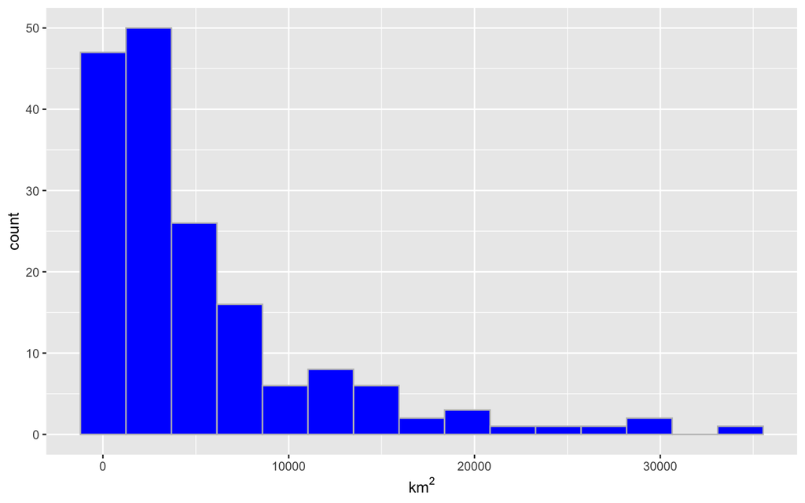

```r
# Chunk 22
districts %>%
  st_area() %>% units::set_units("km^2") %>%
  as.numeric() %>%
  tibble(km2 = .) %>%
  ggplot() +
  geom_histogram(aes(x = km2), bins = 15, fill = "blue", col = "grey") +
  xlab(bquote("km"^2))
```

Here’s a look at the district areas (in km$^2$) as a histogram. Notice the conversion steps. First we wanted to convert the calculated areas to a numeric vector (rather than one of class `units`), using `as.numeric`, then we made it into a `tibble`, because `ggplot` only works with `data.frame`, and then we plotted the histogram. There is one new addition there–in `xlab`, we use `bquote` to print a superscript 2 in the km$^2$ axis label.

### 4.1.2 Distance

We can also calculate the distances between spatial features. To do that, we are make use of `st_centroid` on the Albers-projected `districts` data, which we use to find the central coordinates of each district, and then plot the centroids on top of the districts themselves.

```r
# Chunk 23
# # 1
dist_cent <- districts %>%
  st_transform(., st_crs(roads)) %>%
  st_centroid()
```

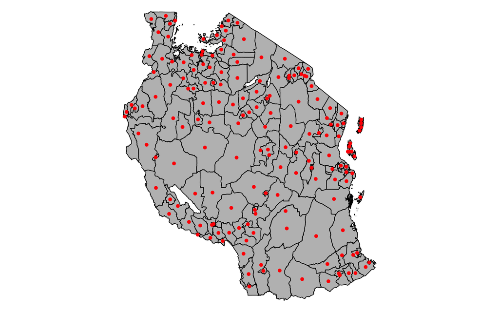

```r
# dist_cent <- st_centroid(st_transform(districts, st_crs(roads)))  # equivalent

# #2
par(mar = c(0, 0, 0, 0))
districts %>%
  st_transform(., st_crs(roads)) %>%
  st_geometry() %>%
  plot(col = "grey")
dist_cent %>%
  st_geometry() %>%
  plot(col = "red", pch = 20, add = TRUE)
```

Notice that right below the centroid calculation pipeline (#1) is a commented out line, which is the non-pipeline equivalent of the operation. In #2, we make the plots, setting up the plotting functions for both the `districts` polygons and their centroids on the downstream ends of pipelines.

Moving on, we can now find out how far apart the centroids of each district are by using another `sf` function, `st_distance`

```r
# Chunk 24
# #1
all_dists <- st_distance(x = dist_cent)
all_dists[1:5, 1:5]
```

```
#> Units: [m]
#>           1         2        3         4         5
#> 1      0.00  10773.52 131963.4  76784.10  22154.92
#> 2  10773.52      0.00 129079.6  86863.41  26309.87
#> 3 131963.35 129079.64      0.0 147658.87 153955.95
#> 4  76784.10  86863.41 147658.9      0.00  84144.27
#> 5  22154.92  26309.87 153956.0  84144.27      0.00
```

```r
#
# #2
d1_dists <- st_distance(x = dist_cent[1, ], y = dist_cent[-1, ])
d1_dists %>% as.vector()
```

```
#>   [1]  10773.52 131963.35  76784.10  22154.92  48224.76 147078.03 495663.62 474665.43 514089.82
#>  [10] 353886.60 362278.55 250294.34 340275.66 184677.86 316956.16 406549.64 527641.50 521549.31
#>  [19] 470564.45 468628.64 423168.10 516170.47 529745.02 529970.53 612782.56 628895.99 566686.88
#>  [28] 575019.66 560010.92 609614.35 659079.91 605944.44 562199.71 624234.34 373298.61 380520.11
#>  [37] 402797.82 410925.40 640600.59 700882.58 692258.56 709156.11 599117.31 662530.06 697844.47
#>  [46] 598375.94 736838.39 749211.47 714257.32  53531.44  76012.40  67721.81 108887.05  88347.56
#>  [55] 162428.80  52353.39 390902.41 394763.98 434482.54 458452.81 723316.19 841413.35 839203.18
#>  [64] 719158.31 849623.83 827749.66 124030.35 140713.62 200709.66 223305.43 161159.43 122529.49
#>  [73] 327921.31 343648.81 366292.29 369469.86 363178.41 257102.36 326563.80 618376.01 787743.39
#>  [82] 638355.70 743121.93 736326.31 762474.50 427043.00 424225.69 340853.12 598637.28 431458.14
#>  [91] 471510.98 419398.57 386654.23 675532.75 910230.56 901426.95 910836.04 898345.07 925203.27
#> [100] 911874.62 920602.72 397994.98 353407.25 351071.53 383560.81 397869.36 440686.55 412550.04
#> [109] 812784.29 681952.75 743611.48 712947.98 753428.93 709107.31 394265.91 454764.07 458753.23
#> [118] 501837.23 622868.53 530822.22 580031.95 809714.84 770461.52 758146.10 759308.41 895288.77
#> [127] 862583.81 948485.07 845917.06 870659.86 901352.65 450843.31 427350.51 305811.30 373118.50
#> [136] 337148.28 262813.88 321876.85 237240.89 300375.88 229361.05 308646.42 279916.68 430791.06
#> [145] 227841.42 240168.50 269285.41 797281.67 770562.91 784042.08 667158.50 811102.94 332184.61
#> [154] 546569.30 399846.38 489949.70 447580.36 523652.09 408873.43 311721.24 285328.88 272796.22
#> [163] 251161.26 284139.82 230940.61 285163.28 305912.46 346104.37 319510.29
```

```r
#
# #3
d1_dists %>%
  as.vector() %>%
  quantile() / 1000
```

```
#>        0%       25%       50%       75%      100%
#>  10.77352 321.87685 450.84331 692.25856 948.48507
```

### 4.1.3 Length

For the last example of functions that extract spatial properties, we will calculate the line lengths and perimeters.

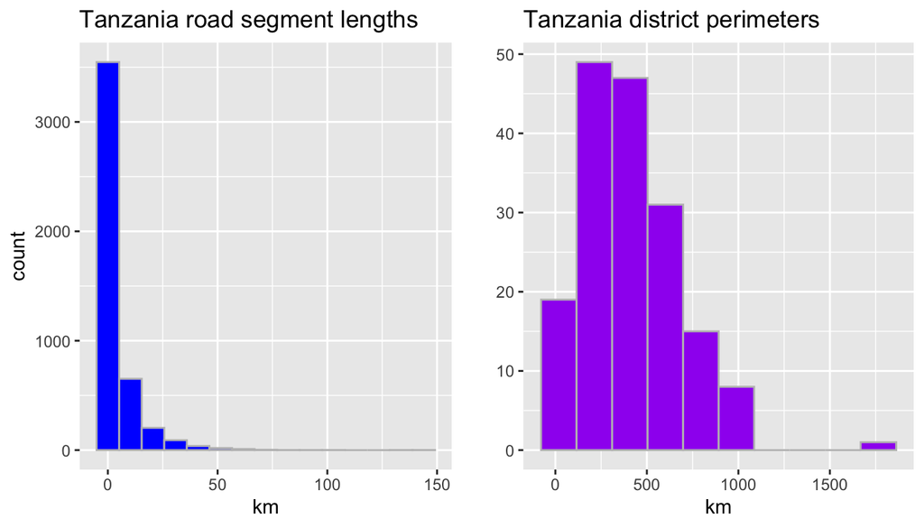

```r
# Chunk 25
# #1
## WARNING: when use as.numeric(), keep in mind the original unit
road_length <- st_length(roads) %>% as.numeric()
#
# #2
dist_perims <- st_length(districts) %>% as.numeric()
#
# #3
p1 <- ggplot(tibble(x = road_length), aes(x / 1000)) +
  geom_histogram(fill = "blue", col = "grey", bins = 15) + xlab("km") +
  ggtitle("Tanzania road segment lengths")
p2 <- ggplot(tibble(x = dist_perims), aes(x / 1000)) +
  geom_histogram(fill = "purple", col = "grey", bins = 10) + xlab("km") +
  ylab("") + ggtitle("Tanzania district perimeters")
cowplot::plot_grid(p1, p2)
```

We use `st_length` to calculate the length of the line segments in `roads` (#1) and the perimeter length of the polygons in `district` (#2), converting both to numeric vectors. We then plot each set of lengths as histograms (#3), converting units to kilometers (by dividing by 1000, within `geom_histogram`), and then use `cowplot::plot_grid` to arrange the two histograms side-by-side.

## 4.2 Manipulating attributes

`sf` objects stores attributes as `data.frame`s or `tibble`s, and they can be manipulated using the same preparatory and analytical methods we learned about in the previous modules. For example, let’s consider some very basic subsetting:

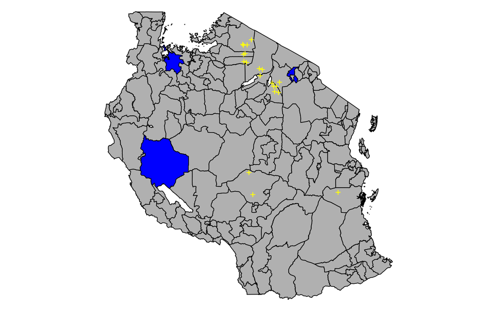

```r
# Chunk 26
par(mar = c(0, 0, 0, 0))
st_geometry(districts) %>% plot(col = "grey")
districts %>%
  slice(1, 20, 40) %>%
  plot(col = "blue", add = TRUE)
set.seed(123)
species %>%
  sample_n(20) %>%
  st_geometry() %>%
  plot(col = "yellow", pch = "+", add = TRUE)
```

Notice the use of `dplyr` verbs to subset two datasets on the fly before they are piped into `plot`. The plot as setup with all `districts` as a backdrop (using `st_geometry` to strip away the attribute table), and then we overlay on that in blue the 1st, 20th, and 40th district, `slice`d out of `districts`. On top of that, we take a random sample of 20 observations from `species`, and plot those on top. You can also index into the `sf` objects with `[]`:

```r
# Chunk 27
par(mar = c(0, 0, 0, 0))
plot(st_geometry(districts), col = "grey")
plot(districts[c(1, 20, 40), ], col = "blue", add = TRUE)
set.seed(123)
plot(st_geometry(species[sample(1:nrow(species), 20), ]), col = "yellow",
     pch = "+", add = TRUE)
```

The code above makes the identical plot as in Chunk 26, so we don’t display that again, but note the indexing, as well as the lack of piping and more conventional syntax.

### 4.2.1 Mutating and joining

The Spatial Properties showed how to calculate area, length, and other properties as separate outputs. Why not add them stick them in separate data objects. Now let’s see how to add those properties back the `sf` attribute `tibble`.

```r
# Chunk 27
## WARNING: when use as.numeric(), keep in mind the original unit
districts %>% mutate(area = as.numeric(st_area(.) / 10^6))
```

```
#> Simple feature collection with 170 features and 2 fields
#> Geometry type: MULTIPOLYGON
#> Dimension:     XY
#> Bounding box:  xmin: 29.58953 ymin: -11.76235 xmax: 40.44473 ymax: -0.983143
#> Geodetic CRS:  WGS 84
#> First 10 features:
#>        distName                       geometry       area
#> 1        Arusha MULTIPOLYGON (((36.82231 -3...  1237.1814
#> 2  Arusha Urban MULTIPOLYGON (((36.63247 -3...   266.9919
#> 3        Karatu MULTIPOLYGON (((35.89154 -3...  3237.7967
#> 4       Longido MULTIPOLYGON (((36.35742 -3...  8064.1221
#> 5          Meru MULTIPOLYGON (((36.89951 -3...  1265.9475
#> 6       Monduli MULTIPOLYGON (((36.54092 -3...  6981.4622
#> 7    Ngorongoro MULTIPOLYGON (((35.32059 -1... 15909.0015
#> 8         Ilala MULTIPOLYGON (((39.21843 -6...   364.9695
#> 9     Kinondoni MULTIPOLYGON (((39.27007 -6...   538.9068
#> 10       Temeke MULTIPOLYGON (((39.3143 -6....   728.7056
```

So that’s a fairly straightforward way to do it. Just use `mutate` with `st_area` (note that `st_area` needs the `.` in it to function correctly). In making a new *area* column, we divide by 10$^6$ to convert to km$^2$, and coerce the result to numeric.

Imagine that someone gave you a separate dataset that simply listed district names and their areas for Tanzania, but provided no other spatial information. Say they did something like this:

```r
# Chunk 28
dist_area <- tibble(distName = districts$distName,
                    area = as.numeric(st_area(districts)) / 10^6)
```

We could use a `*_join` to merge this onto `districts`:

```r
# Chunk 29
left_join(districts, dist_area, by = "distName")
```

```
#> Simple feature collection with 170 features and 2 fields
#> Geometry type: MULTIPOLYGON
#> Dimension:     XY
#> Bounding box:  xmin: 29.58953 ymin: -11.76235 xmax: 40.44473 ymax: -0.983143
#> Geodetic CRS:  WGS 84
#> First 10 features:
#>        distName       area                       geometry
#> 1        Arusha  1237.1814 MULTIPOLYGON (((36.82231 -3...
#> 2  Arusha Urban   266.9919 MULTIPOLYGON (((36.63247 -3...
#> 3        Karatu  3237.7967 MULTIPOLYGON (((35.89154 -3...
#> 4       Longido  8064.1221 MULTIPOLYGON (((36.35742 -3...
#> 5          Meru  1265.9475 MULTIPOLYGON (((36.89951 -3...
#> 6       Monduli  6981.4622 MULTIPOLYGON (((36.54092 -3...
#> 7    Ngorongoro 15909.0015 MULTIPOLYGON (((35.32059 -1...
#> 8         Ilala   364.9695 MULTIPOLYGON (((39.21843 -6...
#> 9     Kinondoni   538.9068 MULTIPOLYGON (((39.27007 -6...
#> 10       Temeke   728.7056 MULTIPOLYGON (((39.3143 -6....
```

In this case a `left_join` works because the number of records is identical and each row in each dataset has a unique district name.

### 4.2.2 More subsetting

We have already done a bit of this a couple of sections back, but let’s use this opportunity to do a bit more subsetting, including a previously unseen approach:

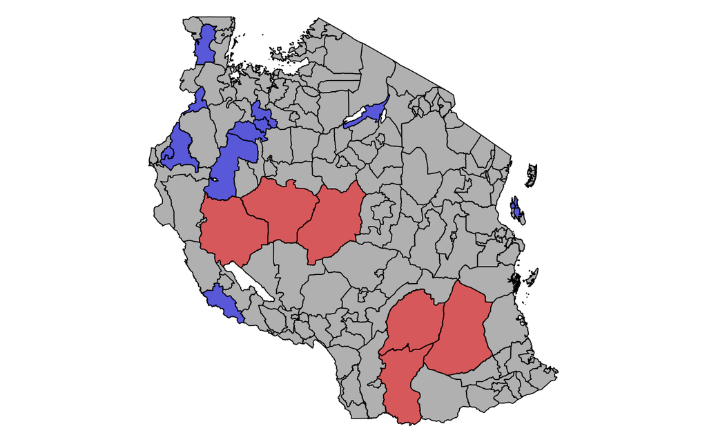

```r
# Chunk 30
# #1
kanyi_dists <- districts %>% filter(grepl("^Ka|^Nyi", distName))
#
# #2
dists_gt2m <- districts %>% filter(as.numeric(st_area(.) / 10^6) > 20000)

par(mar = c(0, 0, 0, 0))
plot(st_geometry(districts), col = "grey")
plot(st_geometry(kanyi_dists), col = rgb(0, 0, 1, alpha = 0.5), add = TRUE)
plot(st_geometry(dists_gt2m), col = rgb(1, 0, 0, alpha = 0.5), add = TRUE)
```

### 4.2.3 Split-apply-combine

```r
# Chunk 30
# #1
tertiles <- function(x) quantile(x, probs = c(0, 0.333, 0.667, 1))
dist_tertiles <- districts %>%
  mutate(area = as.numeric(st_area(.)) / 10^6) %>%
  mutate(acls = cut(area, breaks = tertiles(area), include.lowest = TRUE)) %>%
  group_by(acls) %>%
  summarize(mean_area = mean(area))
```

```
#> although coordinates are longitude/latitude, st_union assumes that they are planar
```

```r
dist_tertiles
```

```
#> Simple feature collection with 3 features and 2 fields
#> Geometry type: MULTIPOLYGON
#> Dimension:     XY
#> Bounding box:  xmin: 29.58953 ymin: -11.76235 xmax: 40.44473 ymax: -0.983143
#> Geodetic CRS:  WGS 84
#> # A tibble: 3 × 3
#>   acls                mean_area                                                             geometry
#>   <fct>                   <dbl>                                                   <MULTIPOLYGON [°]>
#> 1 [15.5,1.51e+03]          651. (((32.75855 -9.249037, 32.76249 -9.252446, 32.76649 -9.254365, 32.7…
#> 2 (1.51e+03,5.19e+03]     3146. (((31.4864 -7.460071, 31.4871 -7.461485, 31.48803 -7.465252, 31.487…
#> 3 (5.19e+03,3.43e+04]    11765. (((35.86454 -11.41009, 35.86409 -11.41199, 35.8631 -11.41347, 35.86…
```

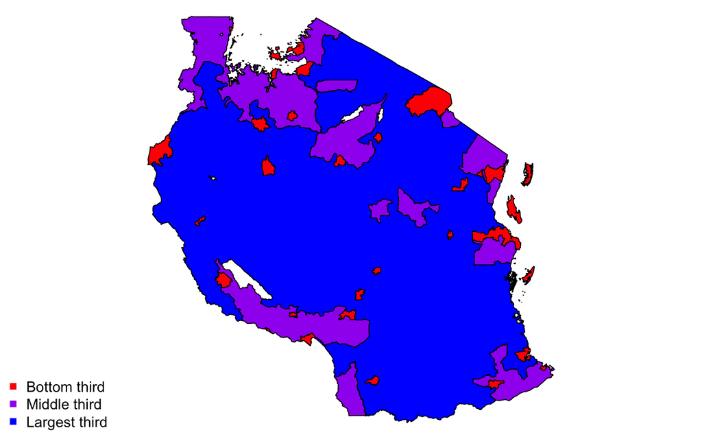

```r
#
# #2
par(mar = rep(0, 4))
plot(st_geometry(dist_tertiles), col = c("red", "purple", "blue"))
legend(x = "bottomleft", pch = 15, col = c("red", "purple", "blue"),
       bty = "n", legend = c("Bottom third", "Middle third", "Largest third"))
```

The above is a `dplyr`-based split-apply-combine, which has a fair bit going on, so let’s explain:

- We first create a new function called `tertiles`, which will divide any vector `x` it is given into thirds.
- In the pipeline, the first line does the usual creation of an *area* variable. The second line use the `cut` function (see `?cut`) to classify the *area* variable into thirds (i.e. districts whose areas are below the 33rd percentile area, those between the 33rd and 66th percentile areas, and those above the 66th percentile), using our `tertile` function, resulting in a new `acls` variable.
- The third line in the pipeline groups the data by `acls`, and then calculates the mean area of each group. This `summarize` is spatial, in that it aggregates (dissolves) the polygons that are in group into a single large polygon for each group, while creating an output value describing the average area of the districts that were unioned to make each group. This is achieved by a generic `summarize` method defined for `sf` (see `?summarise.sf`).
- The `plot` shows the result of the union (plus a legend that we add)

We can do the same thing for standard deviation, but using a quintile grouping:

```r
# Chunk 31
quintiles <- function(x) quantile(x, probs = seq(0, 1, 0.2))
dist_quintiles <- districts %>%
  mutate(area = as.numeric(st_area(.)) / 10^6) %>%
  mutate(acls = cut(area, breaks = quintiles(area), include.lowest = TRUE)) %>%
  group_by(acls) %>%
  summarize(sd_area = sd(area))
```

```
#> although coordinates are longitude/latitude, st_union assumes that they are planar
```

```r
dist_quintiles
```

```
#> Simple feature collection with 5 features and 2 fields
#> Geometry type: MULTIPOLYGON
#> Dimension:     XY
#> Bounding box:  xmin: 29.58953 ymin: -11.76235 xmax: 40.44473 ymax: -0.983143
#> Geodetic CRS:  WGS 84
#> # A tibble: 5 × 3
#>   acls               sd_area                                                                geometry
#>   <fct>                <dbl>                                                      <MULTIPOLYGON [°]>
#> 1 [15.5,718]            192. (((32.75855 -9.249037, 32.76249 -9.252446, 32.76649 -9.254365, 32.7674…
#> 2 (718,2.11e+03]        408. (((33.44827 -9.187084, 33.44973 -9.191858, 33.45134 -9.195909, 33.4525…
#> 3 (2.11e+03,4e+03]      546. (((31.01872 -2.843939, 31.01967 -2.84478, 31.01979 -2.846578, 31.02241…
#> 4 (4e+03,7.9e+03]      1097. (((32.44603 -8.245552, 32.44556 -8.246121, 32.44575 -8.24695, 32.44642…
#> 5 (7.9e+03,3.43e+04]   6703. (((35.86124 -11.41664, 35.85951 -11.41725, 35.85778 -11.41777, 35.8556…
```

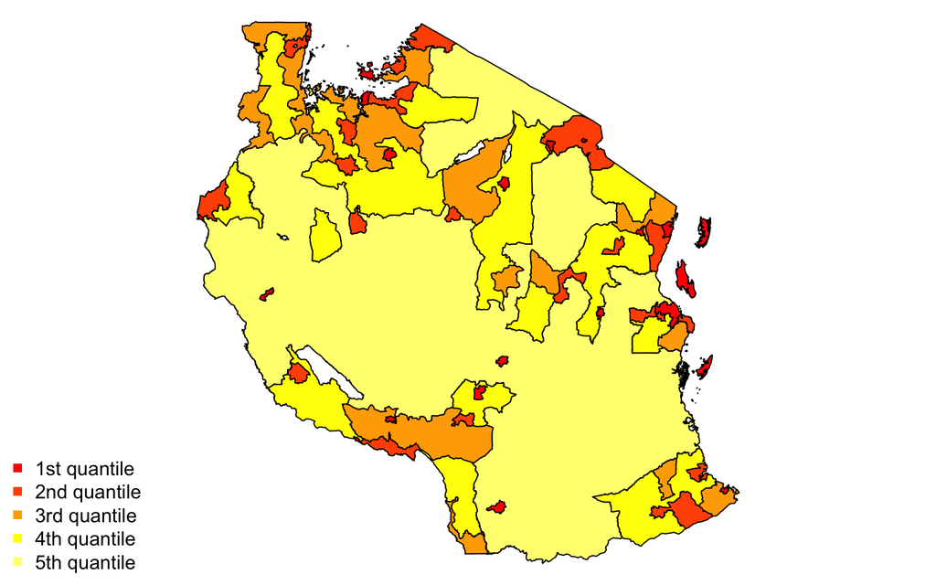

```r
cols <- heat.colors(5)
par(mar = rep(0, 4))
plot(st_geometry(dist_quintiles), col = cols)
legend(x = "bottomleft", pch = 15, col = cols, bty = "n",
       legend = paste0(1:5, c("st", "nd", "rd", "th", "th"), " quantile"))
```

Our plot in this case uses the `heat.colors()` function for filling the polygons.

That was a quick introduction to SAC for `sf`. There are others we could do (you can visit the [tidyverse examples](https://r-spatial.github.io/sf/reference/tidyverse.html) page for `sf` to see some others), but we will move on to the learn about other spatial operations now.

## 4.3 Practice

### 4.3.1 Questions

1. How different are areas calculated using projected and unprojected (geographic) coordinate systems when using `st_area`? How come `st_area` “knows” how to calculate an area in m$^2$ when the CRS is unprojected (the answer isn’t in the material above, but can be found if you read through `?st_area`)?
2. You will note that we haven’t used `ggplot() + geom_sf()` in this section. Why is that?
3. How can we create a grouping variable that we can use to split an `sf` object according to different levels of spatial properties (e.g. area)?

### 4.3.2 Code

1. Using a seed of 1, randomly select (`sample_n`) 10 districts from `districts` and calculate their average area in hectares.
2. Using a seed of 1, randomly select (`sample_n`) 100 road segments from `roads` and calculate their average length in kilometers.
3. Plot districts with a “lightgrey” background, and then randomly select (seed of 1) 200 observations from species of Syncerus caffer, and plot them as red circles over `districts`.
4. From `road` select the roads that have lengths between 50 and 100 km and plot those in red over districts. Note that `districts` and `roads` are in different projections, so transform `district` to have the same CRS as `roads` first.
5. Hack the code in Chunk 31 to create a map of districts merged by their deciles of area. Do the summary by total area. To do this, the `quantile` function will have to be altered (pass `seq(0, 1, 0.1)` to “probs”), and make sure your color vector has enough values.

# 5 Spatial Operations

In this section we will focus on some of the more common polygon-based spatial operations. To enable this, we are first going to create some additional spatial data.

```r
# Chunk 32
# #1
coords <- cbind("x" = c(34.2, 34.3, 35.6, 35.6, 35.6, 34.2),
                "y" = c(-4.8, -3.8, -3.9, -4.1, -4.9, -4.8))
#
# #2
pol <- st_polygon(x = list(coords)) %>%
  st_sfc %>%
  st_sf(ID = 1, crs = 4326)
pol
```

```
#> Simple feature collection with 1 feature and 1 field
#> Geometry type: POLYGON
#> Dimension:     XY
#> Bounding box:  xmin: 34.2 ymin: -4.9 xmax: 35.6 ymax: -3.8
#> Geodetic CRS:  WGS 84
#>   ID                              .
#> 1  1 POLYGON ((34.2 -4.8, 34.3 -...
```

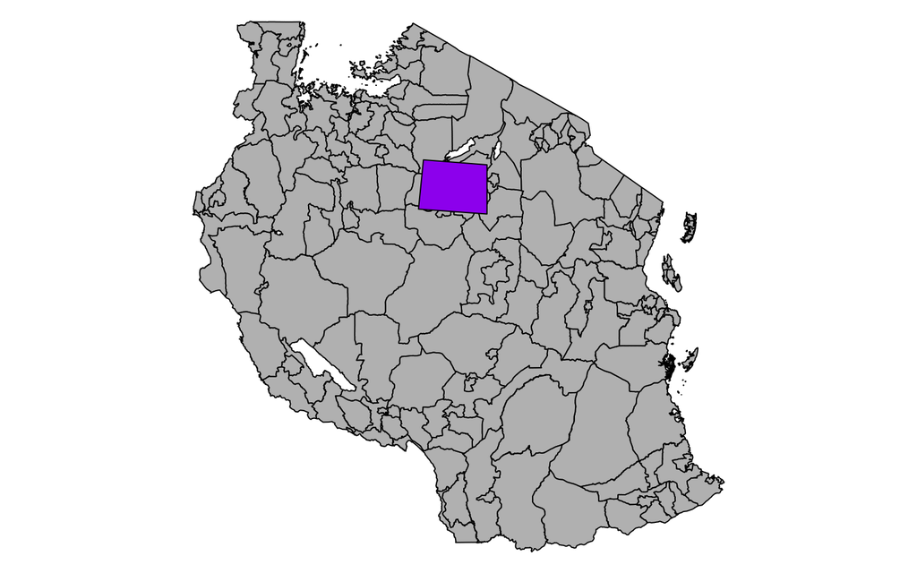

```r
par(mar = rep(0, 4))
plot(st_geometry(districts), col = "grey")
plot(pol, col = "purple", add = TRUE)
```

The above takes `coords`, a `matrix` of x and y coordinates (#1), and repeats the approach we used in Chunk 19 (Section 3.6) to create an `st_polygon` (#2), but then continues on to convert that to a simple feature geometry list column (`st_sfc`), then to create an `sf`, a “data.frame-like object…with a simple feature list column” (`?st_sf`), including the assignment of a CRS. That’s how you build up a full simple feature with attributes.

## 5.1 Overlays/spatial queries

The first thing we will do with our made-up polygon is figure out which districts it intersects. What we are going to do in this case is the ArcGIS equivalent of select by spatial location (if I remember my ESRI terminology correctly–it’s been a while since I looked at it)

```r
# Chunk 32
# #1
st_intersects(x = pol, y = districts)
```

```
#> although coordinates are longitude/latitude, st_intersects assumes that they are planar
#> Sparse geometry binary predicate list of length 1, where the predicate was `intersects'
#>  1: 3, 13, 15, 68, 70, 72, 142, 143, 144, 146, ...
```

```r
#
# #2
dists_int <- districts %>% slice(st_intersects(x = pol, y = districts)[[1]])
```

```
#> although coordinates are longitude/latitude, st_intersects assumes that they are planar
```

```r
dists_int
```

```
#> Simple feature collection with 12 features and 1 field
#> Geometry type: MULTIPOLYGON
#> Dimension:     XY
#> Bounding box:  xmin: 33.91347 ymin: -5.683134 xmax: 36.34537 ymax: -2.928766
#> Geodetic CRS:  WGS 84
#> First 10 features:
#>    distName                       geometry
#> 1    Karatu MULTIPOLYGON (((35.89154 -3...
#> 2    Chemba MULTIPOLYGON (((35.35449 -4...
#> 3    Kondoa MULTIPOLYGON (((35.65407 -4...
#> 4    Babati MULTIPOLYGON (((35.72509 -3...
#> 5    Hanang MULTIPOLYGON (((34.92725 -4...
#> 6     Mbulu MULTIPOLYGON (((35.36185 -3...
#> 7     Meatu MULTIPOLYGON (((34.09986 -3...
#> 8    Ikungi MULTIPOLYGON (((34.59843 -4...
#> 9    Iramba MULTIPOLYGON (((34.50044 -3...
#> 10  Mkalama MULTIPOLYGON (((34.92725 -4...
```

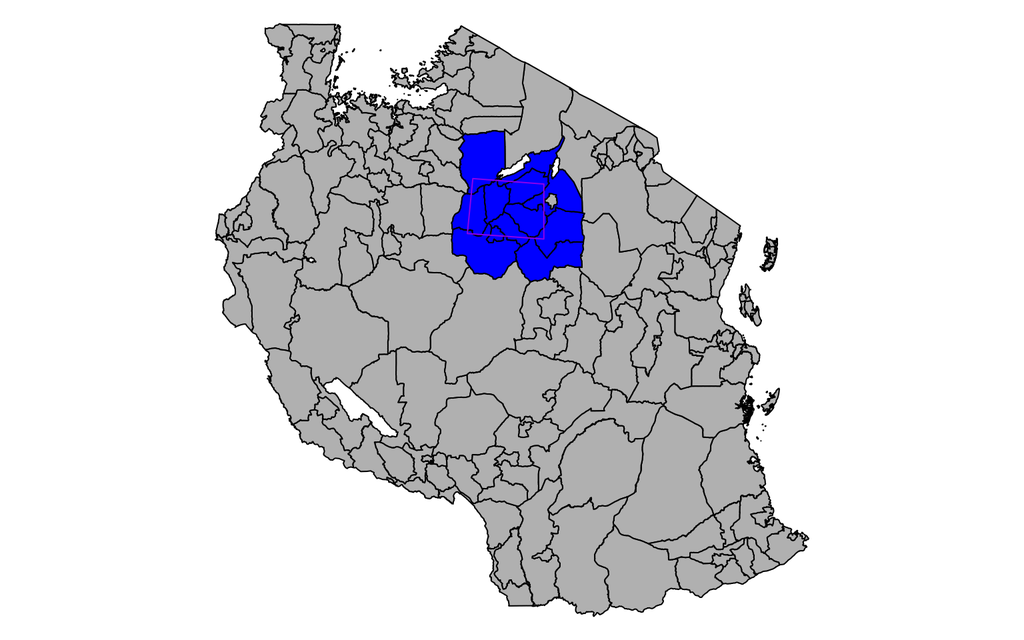

```r
#
# #3
par(mar = rep(0, 4))
plot(st_geometry(districts), col = "grey")
plot(st_geometry(dists_int), col = "blue", add = TRUE)
plot(st_geometry(pol), border = "purple", add = TRUE)
```

## 5.2 Intersecting

We have just seen how `st_intersects` can be used to identify and extract intersecting polygons. Now let’s look at what `st_intersection` does.

```r
# Chunk 33
pol_int_dists <- st_intersection(x = pol, y = districts)
```

```
#> although coordinates are longitude/latitude, st_intersection assumes that they are planar
#> Warning: attribute variables are assumed to be spatially constant throughout all geometries
```

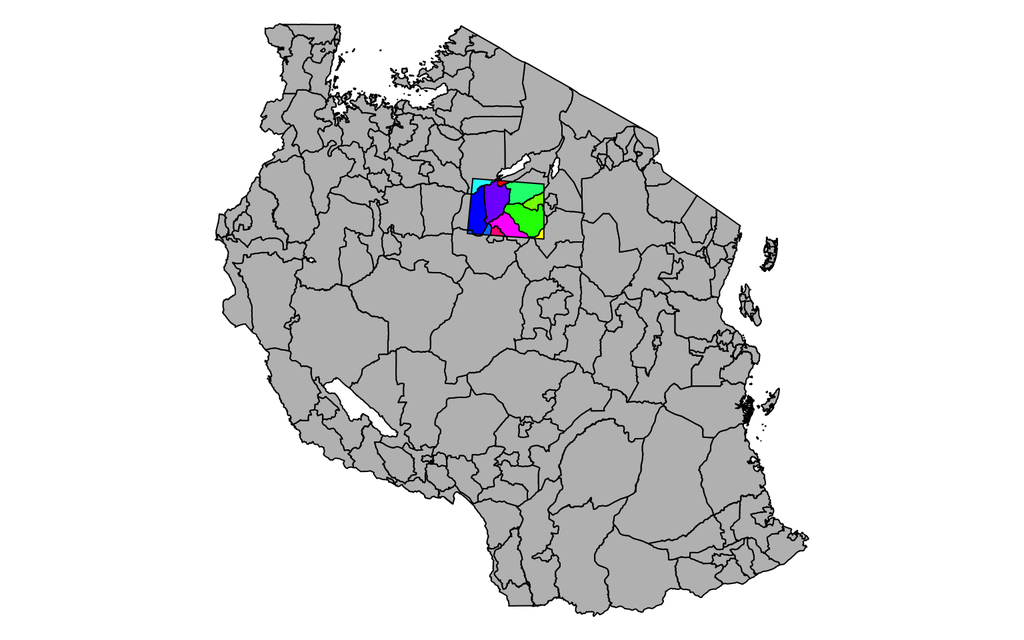

```r
par(mar = rep(0, 4))
plot(st_geometry(districts), col = "grey")
plot(st_geometry(pol_int_dists), col = rainbow(n = nrow(pol_int_dists)),
     add = TRUE)
```

Seems pretty clear what `st_intersection` does, and how it differs from `st_intersects`: it crops the intersected districts to the boundaries of `pol`, and returns the intersected district polygons. It also spits out a warning about the attribute variable being spatially constant, as well as the usual warning about the data not being in planar coordinates. We also introduced another color function (`rainbow`) to distinguish the different intersected districts.

## 5.3 Aggregating/Dissolving

Now that we have intersected boundaries, let’s dissolve them. We’ve actually already seen this (in section 4.2.3), but let’s have a second look:

```r
# Chunk 34
# #1
pol_int_dists %>% summarize
```

```
#> although coordinates are longitude/latitude, st_union assumes that they are planar
#> Simple feature collection with 1 feature and 0 fields
#> Geometry type: POLYGON
#> Dimension:     XY
#> Bounding box:  xmin: 34.2 ymin: -4.9 xmax: 35.6 ymax: -3.8
#> Geodetic CRS:  WGS 84
#>                                .
#> 1 POLYGON ((34.89974 -4.84998...
```

```r
#
# #2
pol_int_muarea <- pol_int_dists %>%
  mutate(area = as.numeric(units::set_units(st_area(.), "km^2"))) %>%
  summarize(area = mean(area))
```

```
#> although coordinates are longitude/latitude, st_union assumes that they are planar
```

```r
pol_int_muarea
```

```
#> Simple feature collection with 1 feature and 1 field
#> Geometry type: POLYGON
#> Dimension:     XY
#> Bounding box:  xmin: 34.2 ymin: -4.9 xmax: 35.6 ymax: -3.8
#> Geodetic CRS:  WGS 84
#>       area                              .
#> 1 1385.954 POLYGON ((34.89974 -4.84998...
```

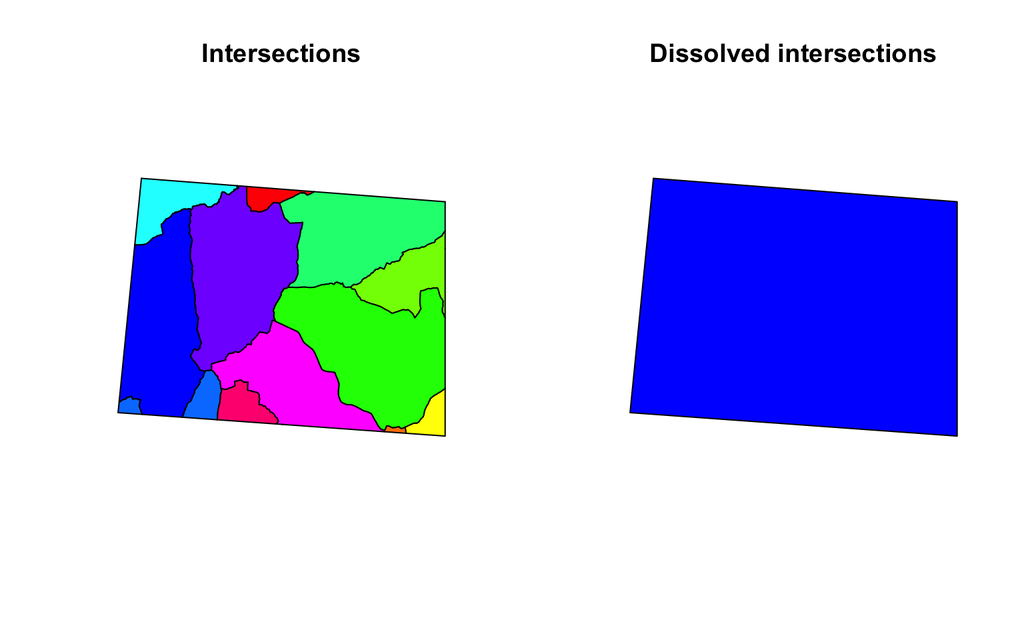

```r
par(mfrow = c(1, 2))
pol_int_dists %>%
  st_geometry() %>%
  plot(col = rainbow(n = nrow(pol_int_dists)), main = "Intersections")
pol_int_muarea %>%
  st_geometry() %>%
  plot(col = "blue", main = "Dissolved intersections")
```

`sf`’s generic for `summarize` does the job for us. In #1, we run `summarize` without specifying a variable to summarize, and it returns a field-less (attribute-less) single polygon (which is identical to `pol`, but not mapped). In #2, we add a variable that is meaningful to summarize, which is the area of the intersected districts. Our summary is the average area of those intersected districts.

For a GIS person, it might be confusing to run a function called summarize when you specifically want to do a dissolve operation. Shouldn’t there be a function named that, or something close to it? Well, there is one: `st_union`, which is actually called by `summarise.sf` (which is called by the generic `summarize` or `summarise` in the presence of an `sf` object) by default. We can see its behavior here:

```r
# Chunk 35
pol_int_dists %>% st_union()
```

[output not shown]

Same result, although in this case it produces a geometry set, and, unlike `summarize`, `st_union` does not retain information about the data values associated with the polygons.

## 5.4 Casting

Sometimes a spatial operation will result in mixed geometry types within a single `sf` object, or a more complex geometry type than you actually need. You might need to make all the geometries in the object uniform (to prevent problems with other functions that don’t want mixed geometry types), or simplify. Doing this is the job of `st_cast`. Let’s look again at `pol_int_dists`

```r
# Chunk 36
pol_int_dists
```

```
#> Simple feature collection with 12 features and 2 fields
#> Geometry type: GEOMETRY
#> Dimension:     XY
#> Bounding box:  xmin: 34.2 ymin: -4.9 xmax: 35.6 ymax: -3.8
#> Geodetic CRS:  WGS 84
#> First 10 features:
#>     ID distName                              .
#> 1    1   Karatu POLYGON ((35.04069 -3.85697...
#> 1.1  1   Chemba POLYGON ((35.33888 -4.88134...
#> 1.2  1   Kondoa POLYGON ((35.6 -4.9, 35.433...
#> 1.3  1   Babati POLYGON ((35.6 -4.1, 35.6 -...
#> 1.4  1   Hanang MULTIPOLYGON (((35.6 -4.696...
#> 1.5  1    Mbulu POLYGON ((35.6 -3.9, 35.6 -...
#> 1.6  1    Meatu POLYGON ((34.3 -3.8, 34.71 ...
#> 1.7  1   Ikungi MULTIPOLYGON (((34.20477 -4...
#> 1.8  1   Iramba POLYGON ((34.27165 -4.08353...
#> 1.9  1  Mkalama POLYGON ((34.75013 -3.83462...
```

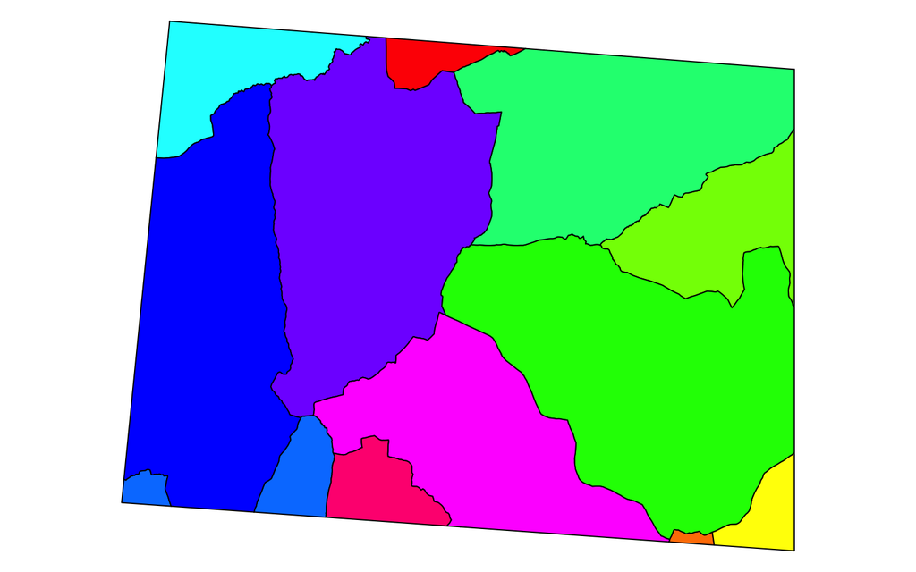

```r
rbcols <- rainbow(n = nrow(pol_int_dists))
par(mar = rep(0, 4))
pol_int_dists %>%
  st_geometry %>%
  plot(col = rbcols)
```

```r
# Chunk 37
pol_int_dists %>% st_cast
```

```
#> Simple feature collection with 12 features and 2 fields
#> Geometry type: MULTIPOLYGON
#> Dimension:     XY
#> Bounding box:  xmin: 34.2 ymin: -4.9 xmax: 35.6 ymax: -3.8
#> Geodetic CRS:  WGS 84
#> First 10 features:
#>     ID distName                              .
#> 1    1   Karatu MULTIPOLYGON (((35.04069 -3...
#> 1.1  1   Chemba MULTIPOLYGON (((35.33888 -4...
#> 1.2  1   Kondoa MULTIPOLYGON (((35.6 -4.9, ...
#> 1.3  1   Babati MULTIPOLYGON (((35.6 -4.1, ...
#> 1.4  1   Hanang MULTIPOLYGON (((35.6 -4.696...
#> 1.5  1    Mbulu MULTIPOLYGON (((35.6 -3.9, ...
#> 1.6  1    Meatu MULTIPOLYGON (((34.3 -3.8, ...
#> 1.7  1   Ikungi MULTIPOLYGON (((34.20477 -4...
#> 1.8  1   Iramba MULTIPOLYGON (((34.27165 -4...
#> 1.9  1  Mkalama MULTIPOLYGON (((34.75013 -3...
```

```r
# Chunk 38
pol_int_dists %>% st_cast("POLYGON")
```

```
#> Warning in st_cast.MULTIPOLYGON(X[[i]], ...): polygon from first part only
#> Warning in st_cast.MULTIPOLYGON(X[[i]], ...): polygon from first part only
#> Simple feature collection with 12 features and 2 fields
#> Geometry type: POLYGON
#> Dimension:     XY
#> Bounding box:  xmin: 34.2 ymin: -4.9 xmax: 35.6 ymax: -3.8
#> Geodetic CRS:  WGS 84
#> First 10 features:
#>     ID distName                              .
#> 1    1   Karatu POLYGON ((35.04069 -3.85697...
#> 1.1  1   Chemba POLYGON ((35.33888 -4.88134...
#> 1.2  1   Kondoa POLYGON ((35.6 -4.9, 35.433...
#> 1.3  1   Babati POLYGON ((35.6 -4.1, 35.6 -...
#> 1.4  1   Hanang POLYGON ((35.6 -4.696429, 3...
#> 1.5  1    Mbulu POLYGON ((35.6 -3.9, 35.6 -...
#> 1.6  1    Meatu POLYGON ((34.3 -3.8, 34.71 ...
#> 1.7  1   Ikungi POLYGON ((34.20477 -4.75227...
#> 1.8  1   Iramba POLYGON ((34.27165 -4.08353...
#> 1.9  1  Mkalama POLYGON ((34.75013 -3.83462...
```

```
#> Warning in st_cast.MULTIPOLYGON(X[[i]], ...): polygon from first part only
#> Warning in st_cast.MULTIPOLYGON(X[[i]], ...): polygon from first part only
```

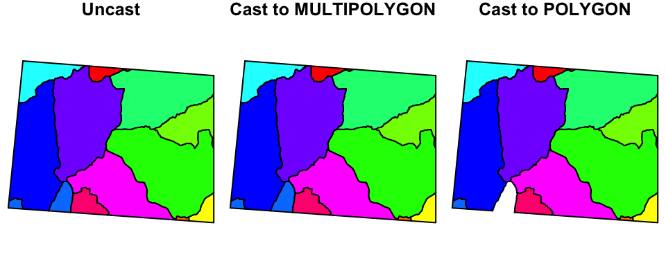

```r
# Chunk 39
par(mfrow = c(1, 3), mar = c(0, 0, 1, 0))
pol_int_dists %>%
  st_geometry %>%
  plot(col = rbcols, main = "Uncast")
pol_int_dists %>%
  st_cast() %>%
  st_geometry %>%
  plot(col = rbcols, main = "Cast to MULTIPOLYGON")
pol_int_dists %>%
  st_cast("POLYGON") %>%
  st_geometry %>%
  plot(col = rbcols, main = "Cast to POLYGON")
```

No difference between the original `pol_int_dists` and the straight cast of it, but when we try cast to POLYGON, the bottom part of the blue district disappears.

**Plotting tip**: note how we add titles to the plots and also tweak the margins to add space to the top margin so that those titles can be displayed.

We can also cast the polygons to lines, and even to points:

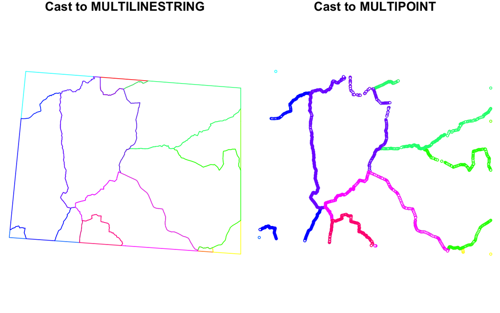

```r
# Chunk 40
par(mfrow = c(1, 2), mar = c(0, 0, 1, 0))
pol_int_dists %>%
  st_cast("MULTILINESTRING") %>%
  st_geometry %>%
  plot(col = rbcols, main = "Cast to MULTILINESTRING")
pol_int_dists %>%
  st_cast("MULTIPOINT") %>%
  st_geometry %>%
  plot(col = rbcols, main = "Cast to MULTIPOINT", pch = 21, cex = 0.5)
```

So that’s `st_cast`. Not really a spatial operation *per se*, but can be important for transitioning between spatial operations, as indicated by this passage from `sf`’s [3rd vignette](https://cran.r-project.org/web/packages/sf/vignettes/sf3.html):

> When functions return objects with mixed geometry type (GEOMETRY), downstream functions such as st_write may have difficulty handling them. For some of these cases, st_cast may help modifying their type. For sets of geometry objects (sfc) and simple feature sets (sf),st_cast` can be used by specifying the target type, or without specifying it.

To learn more `st_cast` and its behavior, please read that vignette.

## 5.5 Differencing

Now we are going to move on to look at another bread and butter operation, differencing (or erasing).

```r
# Chunk 41
d1 <- st_difference(x = districts, y = pol)
```

```
#> although coordinates are longitude/latitude, st_difference assumes that they are planar
#> Warning: attribute variables are assumed to be spatially constant throughout all geometries
```

```r
d2 <- st_difference(x = pol, y = districts)
```

```
#> although coordinates are longitude/latitude, st_difference assumes that they are planar
#> Warning: attribute variables are assumed to be spatially constant throughout all geometries
```

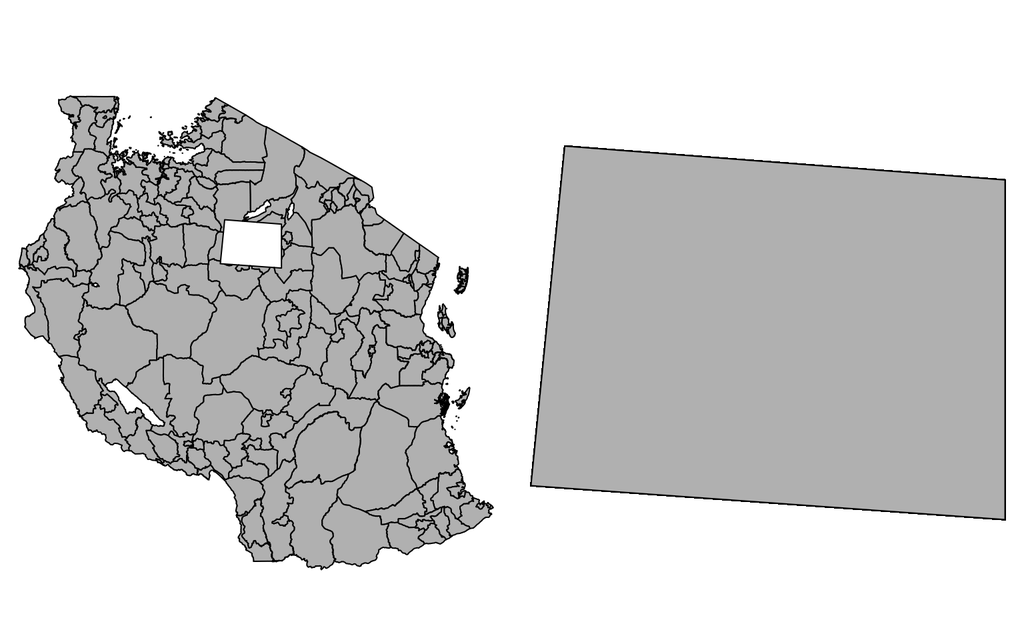

```r
par(mfrow = c(1, 2), mar = c(0, 0, 1, 0))
d1 %>%
  st_geometry %>%
  plot(col = "grey")
d2 %>%
  st_geometry %>%
  plot(col = "grey")
```

`d1` erases `pol`, leaving a hole, whereas `d2`, by reversing the order of objects into the “x” and “y” arguments, does the same thing as an intersection, by erasing all the districts surrounding `pol`.

## 5.6 Unioning

We have already seen `st_union` in action to dissolve internal polygon boundaries. Now let’s look at unioning two objects.

```r
# Chunk 42
# #1
uni1 <- st_union(x = pol, y = districts)
```

```
#> although coordinates are longitude/latitude, st_union assumes that they are planar
#> Warning: attribute variables are assumed to be spatially constant throughout all geometries
```

```r
uni1
```

```
#> Simple feature collection with 170 features and 2 fields
#> Geometry type: GEOMETRY
#> Dimension:     XY
#> Bounding box:  xmin: 29.58953 ymin: -11.76235 xmax: 40.44473 ymax: -0.983143
#> Geodetic CRS:  WGS 84
#> First 10 features:
#>     ID     distName                              .
#> 1    1       Arusha MULTIPOLYGON (((34.2 -4.8, ...
#> 1.1  1 Arusha Urban MULTIPOLYGON (((34.2 -4.8, ...
#> 1.2  1       Karatu POLYGON ((34.3 -3.8, 34.750...
#> 1.3  1      Longido MULTIPOLYGON (((34.2 -4.8, ...
#> 1.4  1         Meru MULTIPOLYGON (((34.2 -4.8, ...
#> 1.5  1      Monduli MULTIPOLYGON (((34.2 -4.8, ...
#> 1.6  1   Ngorongoro MULTIPOLYGON (((34.2 -4.8, ...
#> 1.7  1        Ilala MULTIPOLYGON (((34.2 -4.8, ...
#> 1.8  1    Kinondoni MULTIPOLYGON (((34.2 -4.8, ...
#> 1.9  1       Temeke MULTIPOLYGON (((34.2 -4.8, ...
```

```r
#
# #2
uni2 <- st_union(x = districts, y = pol)
```

```
#> although coordinates are longitude/latitude, st_union assumes that they are planar
#> Warning: attribute variables are assumed to be spatially constant throughout all geometries
```

```r
uni2
```

```
#> Simple feature collection with 170 features and 2 fields
#> Geometry type: GEOMETRY
#> Dimension:     XY
#> Bounding box:  xmin: 29.58953 ymin: -11.76235 xmax: 40.44473 ymax: -0.983143
#> Geodetic CRS:  WGS 84
#> First 10 features:
#>        distName ID                       geometry
#> 1        Arusha  1 MULTIPOLYGON (((36.82231 -3...
#> 2  Arusha Urban  1 MULTIPOLYGON (((36.63247 -3...
#> 3        Karatu  1 POLYGON ((35.88634 -3.26032...
#> 4       Longido  1 MULTIPOLYGON (((36.35742 -3...
#> 5          Meru  1 MULTIPOLYGON (((36.89951 -3...
#> 6       Monduli  1 MULTIPOLYGON (((36.54092 -3...
#> 7    Ngorongoro  1 MULTIPOLYGON (((35.32059 -1...
#> 8         Ilala  1 MULTIPOLYGON (((39.21843 -6...
#> 9     Kinondoni  1 MULTIPOLYGON (((39.27007 -6...
#> 10       Temeke  1 MULTIPOLYGON (((39.3143 -6....
```

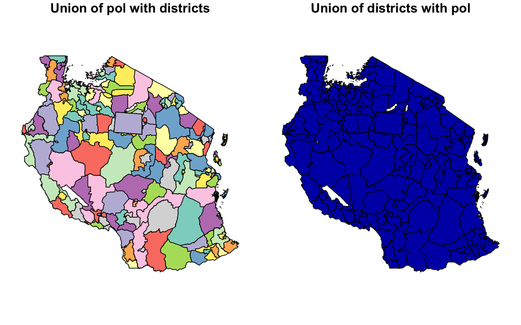

```r
#
# #3
par(mfrow = c(1, 2), mar = c(0, 0, 1, 0))
plot(uni1[2], reset = FALSE, main = "Union of pol with districts")
plot(uni2[2], reset = FALSE, main = "Union of districts with pol")
```

Two different order to unioning `pol` and `districts` (#1 and #2). The ordering simply results in the ordering of the attribute fields in the resulting unioned datasets (the fields from the object in the “x” argument appear first) after the overlapping polygons are merged. You can see the difference in the ordering in the resulting plots (#3), in which for the first time we use index notation to specify the field of each object that we want the plot to render. In this case, we select the second field, which is different in each unioned object, hence the different fill patterns. This index-based referencing is a good way to avoid having to use `st_geometry`, while letting `sf::plot` do the work of selecting a color scheme.

## 5.7 Buffering

This is a fairly common GIS operation that `sf` handles nicely.

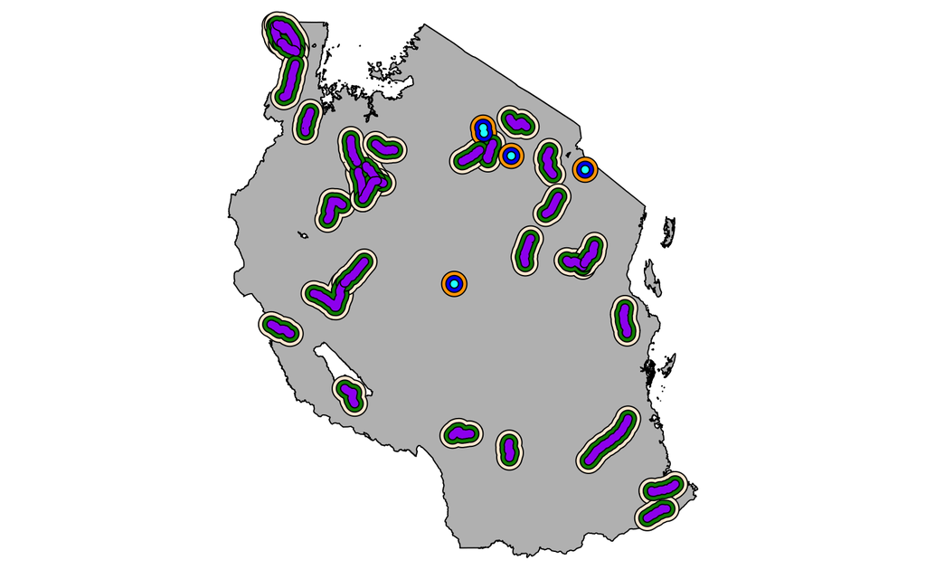

```r
# Chunk 43
#
# #1
species_alb <- species %>% st_transform(st_crs(roads))
long_roads <- roads %>% filter(as.numeric(st_length(.)) > 50000)
districts_alb <- districts %>% st_transform(st_crs(roads))

# #2
buffs <- lapply(c(10000, 20000, 30000), function(x) {
  set.seed(123)
  #2a
  buf_species <- species_alb %>% filter(species == "Syncerus caffer") %>%
    st_sample(size = 5) %>% st_buffer(dist = x) # here is the buffer
  #2b
  buf_roads <- long_roads %>% st_buffer(dist = x)  # here is the buffer
  #2c
  list("species" = buf_species, "roads" = buf_roads)
})
#
# using purrr::map
# buffs <- c(10000, 20000, 30000) %>% map(function(x) {
#   set.seed(123)
#   #2a
#   buf_species <- species_alb %>% filter(species == "Syncerus caffer") %>%
#     st_sample(size = 5) %>% st_buffer(dist = x)
#   #2b
#   buf_roads <- long_roads %>% st_buffer(dist = x)
#   list("species" = buf_species, "roads" = buf_roads)
# })
#
# #3
par(mar = c(0, 0, 0, 0))
cols <- c("cyan", "blue2", "orange")  # 2
cols2 <- c("purple", "green4", "antiquewhite")
districts_alb %>% st_union %>% plot(col = "grey")
for(i in length(buffs):1) {  # 4
  plot(buffs[[i]]$roads, add = TRUE, col = cols2[i])  # 6
  plot(buffs[[i]]$species, add = TRUE, col = cols[i])  # 5
}
```

In #3 we draw the plots, setting up an outline of Tanzania by dissolving district boundaries, then plotting the buffered shapes in a `for` loop (note the reversed index ordering, to plot from largest to smallest buffers).

## 5.8 Sampling

We have seen a little bit of sampling already, but the previous examples just sample from the features in an existing object. Sometimes you might be interested in confining the sample to a particular feature or features, for example:

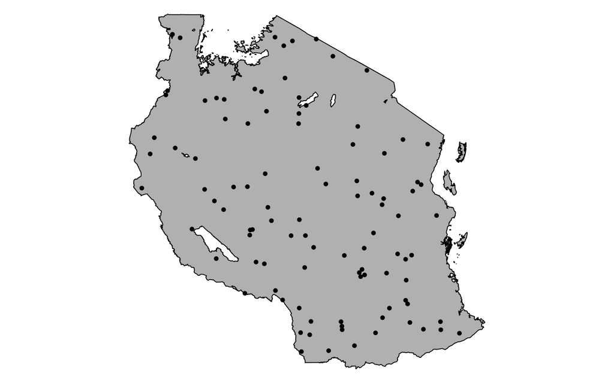

```r
# Chunk 44
par(mar = rep(0, 4))
districts %>%
  st_union %>%
  plot(col = "grey")
set.seed(1)
districts %>%
  st_union %>%
  st_sample(size = 100, exact = TRUE) %>%
  plot(pch = 20, add = TRUE)
```

That uses `st_sample` to pull a random sample of 100 points from within the merged district. We set the `exact = TRUE` argument to force the returned sample to be the exact number we specify (otherwise it can sometimes be a bit less).

Let’s look at this in a bit more depth:

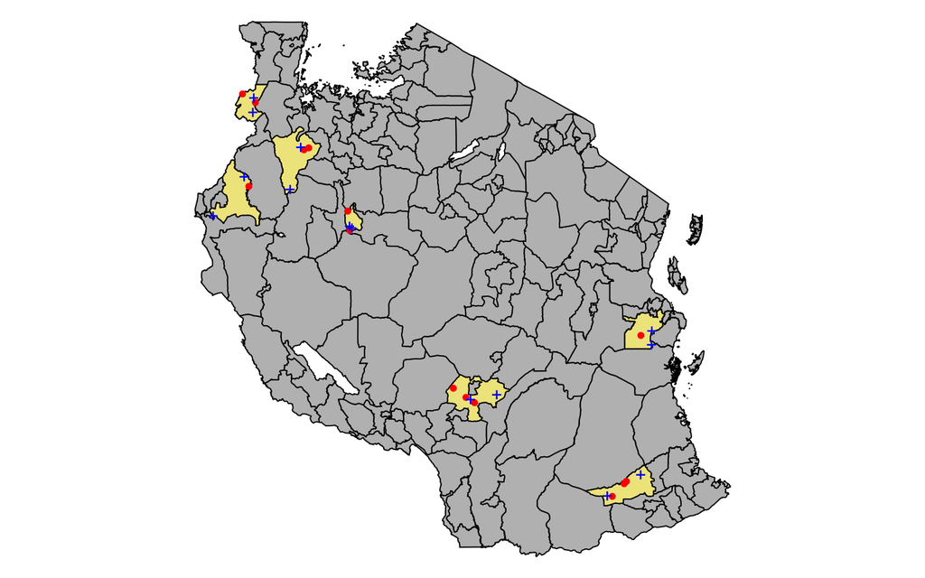

```r
# Chunk 45
# #1
seed <- 40
set.seed(seed)
dists_7 <- districts %>% sample_n(7)
#
# #2
set.seed(seed)
samp14 <- dists_7 %>% st_sample(size = 14, exact = TRUE)
#
# #3
set.seed(seed)
samp7_2 <- dists_7 %>% st_sample(size = rep(2, nrow(dists_7)), exact = TRUE)

par(mar = rep(0, 4))
districts[2] %>% plot(col = "grey", reset = FALSE)
dists_7 %>% plot(col = "khaki", add = TRUE)
samp14 %>% plot(col = "red", pch = 20, add = TRUE)
samp7_2 %>% plot(col = "blue", pch = "+", add = TRUE)
```

In #1 we start by randomly selecting 7 districts from `districts` (using `sample_n`). We then use `st_sample` to randomly select 14 points from within those 7 randomly selected districts (#2). In #3, we specify that we want to randomly select 2 points within each of the 7 districts–to do that, we create a vector containing 2 repeated as many times as there are rows in `dists_7`, so the sample size is specified for each of the 7 sampled districts. The output plots show the differences between the two sampling strategies. The approach used in #2 distributes an unequal number of points across the 7 districts, and misses one district entirely. The approach in #3 places two points in each of the 7 districts. It is not hard to see that one could go from here to create a stratified random sample in which the size was made proportional to each district’s area.

So that’s it for this unit, which has given a brief and by no means exhaustive introduction to do some common vector operations and ways in which vector data are manipulated.

## 5.9 Practice

### 5.9.1 Questions

1. Why it is the purpose of `st_cast`, and why might we need to cast features?
2. What spatial operation occurs when `summarize` is applied to an `sf` object?
3. In what way does the order of unioning affect the result of `st_union` on two spatial objects?

### 5.9.2 Code

1. Using the code in Chunk 32 as your template, create a rectangular `sf` polygon called `pol2` using the x coordinates 35 and 35.5 (minimum and maximum) and y coordinates -4 and -4.5. Coordinates vectors should be ordered like this for x: xmin, xmax, xmax, xmin, xmin. And for y: ymin, ymin, ymax, ymax, ymin. In both cases, think of min and max in absolute terms (i.e. drop the negative sign). Plot the result on top of `districts` in blue. It should look like this:

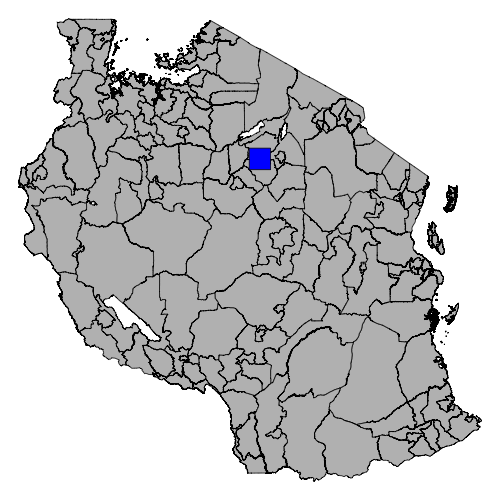

2. Use your new `pol2` to do an `st_intersection` with `districts`. Call it `pol2_int_dists`. Plot it using rainbow colors on top of grey `districts`.
3. Calculate the difference between 1) the sum of areas calculated from `pol2_int_dists` and 2) the area of `pol2`.
4. Use `st_difference` to create a `pol2` sized hole in `districts`. Do the difference on the fly (i.e. don’t save it), and pipe the result to `plot(col = "grey")`
5. From Chunk 43, recreate `species_alb`, and use the code in #2a to recreate buffers of 30 km width around the 5 randomly selected species points, and plot those. Recreate the buffers, but use `sample_n` to do the random draw. Plot those and compare the difference.
6. Select from `roads` the roads that are greater than 40 km long, and save the result in `roads_gt40`. Place a 25 km buffer around those roads. Plot the result over the Albers-projected districts (in grey) in green.
7. Select a random sample of exactly 20 points within each of the 25 km buffers around `roads_gt40`. Plot the resulting points as red circles over the tan buffered roads and grey districts.

# 6 Unit assignment

## 6.1 Set-up

Make sure you are working in the main branch of your project (you should not be working on the a3 branch). Create a new vignette named “unit2_module1.Rmd”. You will use this to document the tasks you undertake for this assignment.

There are no package functions to create for this assignment. All work is to be done in the vignette.

## 6.2 Vignette tasks

1. Read in the `species.csv`, `districts.geojson`, and `roads.geojson` datasets. Convert it to an `sf` object. Reproject the species and districts data to Albers projection (using the CRS from roads), naming each `species_alb` and `districts_alb`. Ideally you will do all the necessary steps to create `species_alb` and `districts_alb` in one pipeline (**worth an extra 0.5 points**).
2. Create a plot using `sf::plot` that shows all three datasets on one map, with `districts_alb` in grey, with `roads` in red over that, and `species_alb` as a blue cross over that. Use the relevant chunk arguments to center the figure in the vignette html, and to have a height of 4 inches and a width of 6 inches (Hints: `fig.align`, `fig.height`, `fig.width`). The figure should have 0 margins all around (Hint: `par`).
3. Make the same plot above using `ggplot` and `geom_sf`. When adding `species_alb` to the plot, use `pch = "+"` and `size = 3` as arguments to `geom_sf`. Add the function `theme_bw()` to the `ggplot` construction chain, to get rid of the grey background. Make the “fill” (rather than “color”) of `districts_alb` grey. Center the figure using chunk options and make the figure width 5 inches and height 6 inches.
4. Select from `districts_alb` the district representing the *50th percentile area*, i.e. the median area, and save that district into a new object `median_dist`. Plot it in “khaki” on top of grey `districts_alb`. Give the plot a title “The median area district”. Same plot dimensions in the vignette html as for Task 2, but a leave a space of 1 at the top in the plot `mar`.
5. Convert the `median_dist` to its centroid point. Call it `median_distp`. `filter` the `species_alb` data for species belonging to family “Felidae”, and then find the 20 closest Felidae species to `median_distp`. To do that, create the new object `closest_20species` by using `mutate` with `st_distance` to create a new variable *dist* (convert it to numeric), and then `arrange` by variable *dist* and slice out the top 20 observations. Use `ggplot2` to plot `districts_alb` in grey, `median_dist` over that in khaki, `median_distp` as a solid purple circle, `species_alb` in blue, and `closest_20species` in red. Zero margins (Hint: use `theme(plot.margin = margin(t = 0, r = 0, b = 0, l = 0, unit = "cm"))` in the `ggplot2` pipeline) and width of 6 inches and height of 4 inches.
6. Create a rectangular `sf` polygon called `mypol` using the x coordinates 32 and 33 (minimum and maximum) and y coordinates -5 and -6. Assign it `crs = 4326` and transform it to Albers. Select from `districts_alb` the districts that intersect `mypol`, and plot in “grey40” over `districts_alb` in grey, and plot over that `mypol` without any fill but just a yellow border. Zero margins and width of 6 inches and height of 4 inches. Calculate the area in ha of `mypol` and report it in your vignette below this plot.
7. Create `mypol_dist_int` from the intersection of `mypol` and `districts_alb`, recasting the intersected districts to multipolygons, and adding an *area* variable onto it that reports areas of intersections in hectares. Do all that in one pipeline. Use `sf::plot` to plot `mypol_dist_int` in rainbow colors over `districts_alb` in grey. Zero margins and width of 6 inches and height of 4 inches. Report the mean and median of intersections in the vignette below the plot.
8. Find the shortest and longest road segments in Tanzania, and place the selected roads into a new object (`roads_extreme`). To do this, you will need to `arrange` `roads` by length and then `slice` to get the first and last observations (of course you need to first calculate length). Do that as one pipeline. Then calculate a 50 km buffer around those two roads (`roads_extreme_buff`). Use `sf::plot` to plot `roads_extreme_buff` in blue over `districts_alb` in grey, and add `roads_extreme` on top of that as red lines (use `lwd = 3` in the plot). Zero margins and width of 6 inches and height of 4 inches.
9. Select a random sample of 10 points in the smallest object, and one of 50 in the largest object in `roads_extreme_buff`. Use a **single** call to `st_sample` to do that (Hint: check the help of function `st_sample`). Use a **seed of 2**. Use `sf::plot` to plot those points as yellow solid points over the same map created in Task 8 above. Use the same dimensions.
10. Your final task is to intersect `roads` with the buffer of the longest road in `roads_extreme_buff` (name the result as `roads_int`). Plot the buffer of the longest road in blue over the districts in grey, and then `roads_int` as red lines. Use the same dimensions as the previous two plots. Report the total distance of intersected roads in km in the vignette below the plot.

## 6.3 Assignment output

Refer to Unit 1 Module 4’s assignment output section for submission instructions. The only differences are as follows:

1. You should increment your package version number by 1 on the lowest number (e.g. from 0.1.2 to 0.1.3) in the DESCRIPTION;
2. When asked to report the result of calculations in the vignette text (e.g. in Task 10), you can use another RMarkdown trick, which is to let the calculation be done by code inserted between a single pair of backticks, with the first backtick followed immediately by r and a space. See [here](https://rmarkdown.rstudio.com/lesson-4.html) for more explanation of that.
3. Revise the setting chunk in the beginning of your vignette to:

   ```markdown
   knitr::opts_chunk$set(
     collapse = TRUE,
     comment = "#>",
     warning = FALSE,
     message = FALSE
   )
   ```

   to avoid unnecessary warning and message.
4. Update vignette title and this line in the YAML header to `%\VignetteIndexEntry{Unit 2 Module 1 assignment 4}`. When you browse the vignettes of your package, you should see a page in your browser like this:

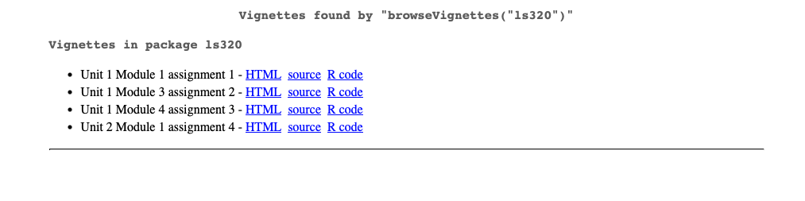

5. Your submission should be on a new side branch “a4”.

Back to home